# Emotional support

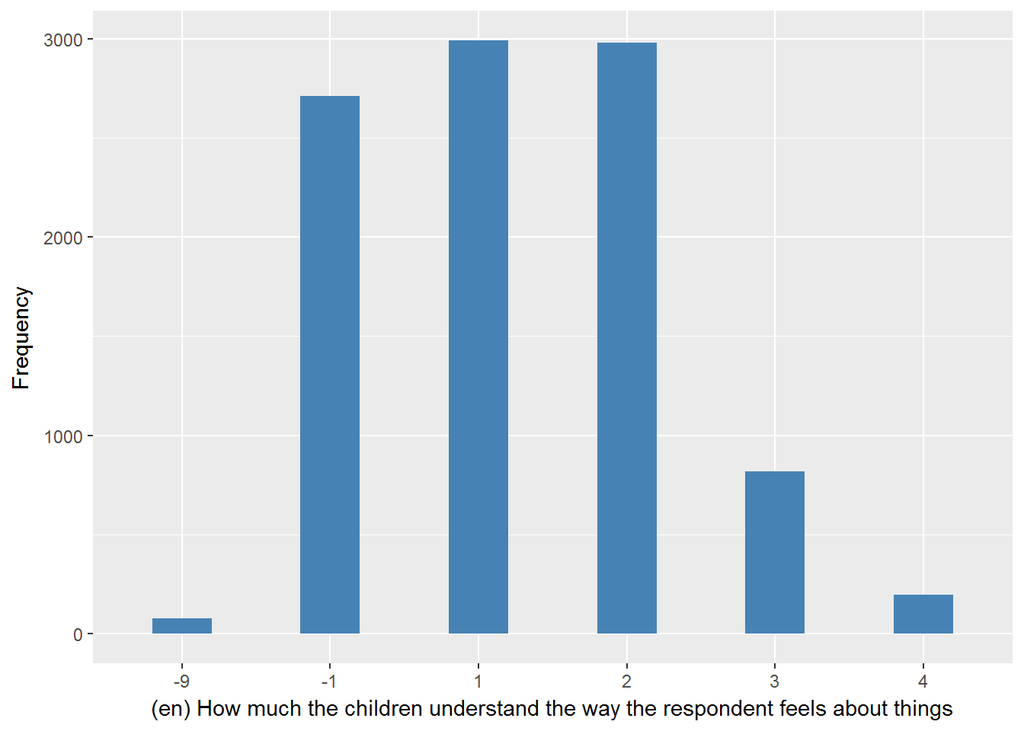

scchdb

| Sample size | Missing values |
| --- | --- |
| 9771 | 2771 |

Category

|  | 1 | 2 | 3 | 4 |
| --- | --- | --- | --- | --- |
| Frequency | 5439.00 | 997.0 | 398.00 | 166.0 |
| Percentage | 55.66 | 10.2 | 4.07 | 1.7 |

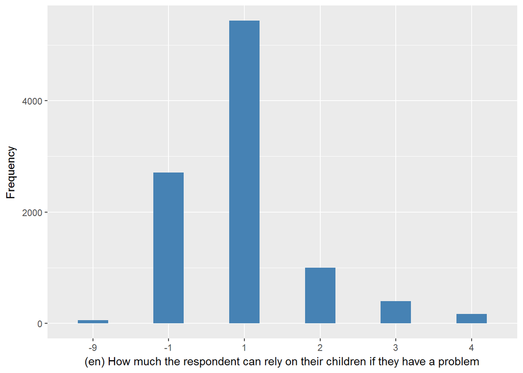

scchdc

| Sample size | Missing values |
| --- | --- |
| 9771 | 2776 |

Category

|  | 1 | 2 | 3 | 4 |
| --- | --- | --- | --- | --- |
| Frequency | 3549.00 | 2264.00 | 889.0 | 293 |
| Percentage | 36.32 | 23.17 | 9.1 | 3 |

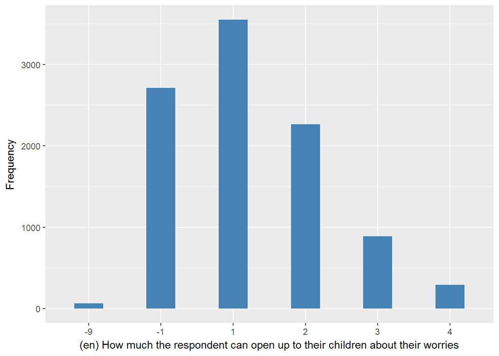

scfama

| Sample size | Missing values |
| --- | --- |
| 9771 | 2364 |

Category

|  | 1 | 2 | 3 | 4 |
| --- | --- | --- | --- | --- |
| Frequency | 1723.00 | 2979.00 | 1889.00 | 816.00 |
| Percentage | 17.63 | 30.49 | 19.33 | 8.35 |

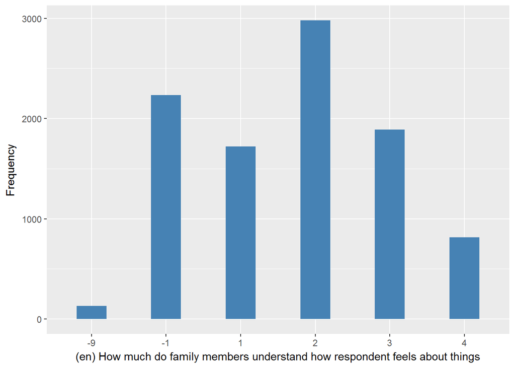

scfamb

| Sample size | Missing values |
| --- | --- |
| 9771 | 2351 |

Category

|  | 1 | 2 | 3 | 4 |
| --- | --- | --- | --- | --- |
| Frequency | 3731.00 | 1767.00 | 1117.00 | 805.00 |
| Percentage | 38.18 | 18.08 | 11.43 | 8.24 |

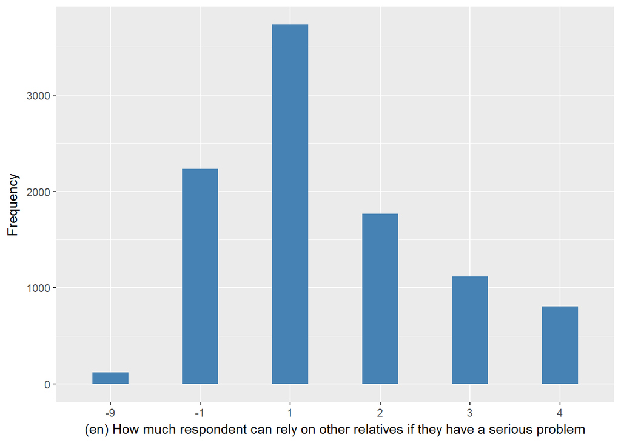

scfamc

| Sample size | Missing values |
| --- | --- |
| 9771 | 2371 |

Category

|  | 1 | 2 | 3 | 4 |
| --- | --- | --- | --- | --- |
| Frequency | 2425.00 | 2232.00 | 1649.00 | 1094.0 |
| Percentage | 24.82 | 22.84 | 16.88 | 11.2 |

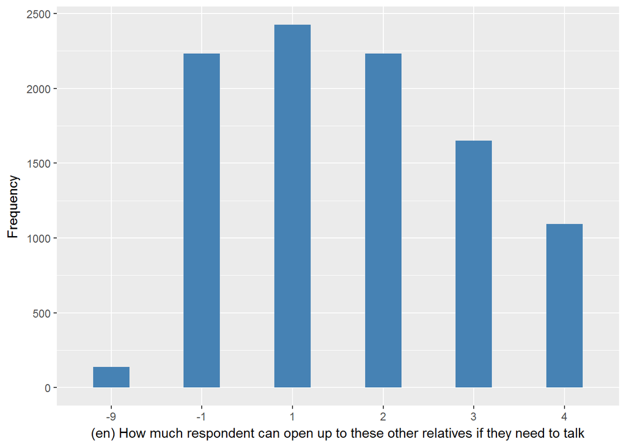

scfrda

| Sample size | Missing values |
| --- | --- |
| 9771 | 2099 |

Category

|  | 1 | 2 | 3 | 4 |
| --- | --- | --- | --- | --- |
| Frequency | 2758.00 | 3486.00 | 1286.00 | 142.00 |
| Percentage | 28.23 | 35.68 | 13.16 | 1.45 |

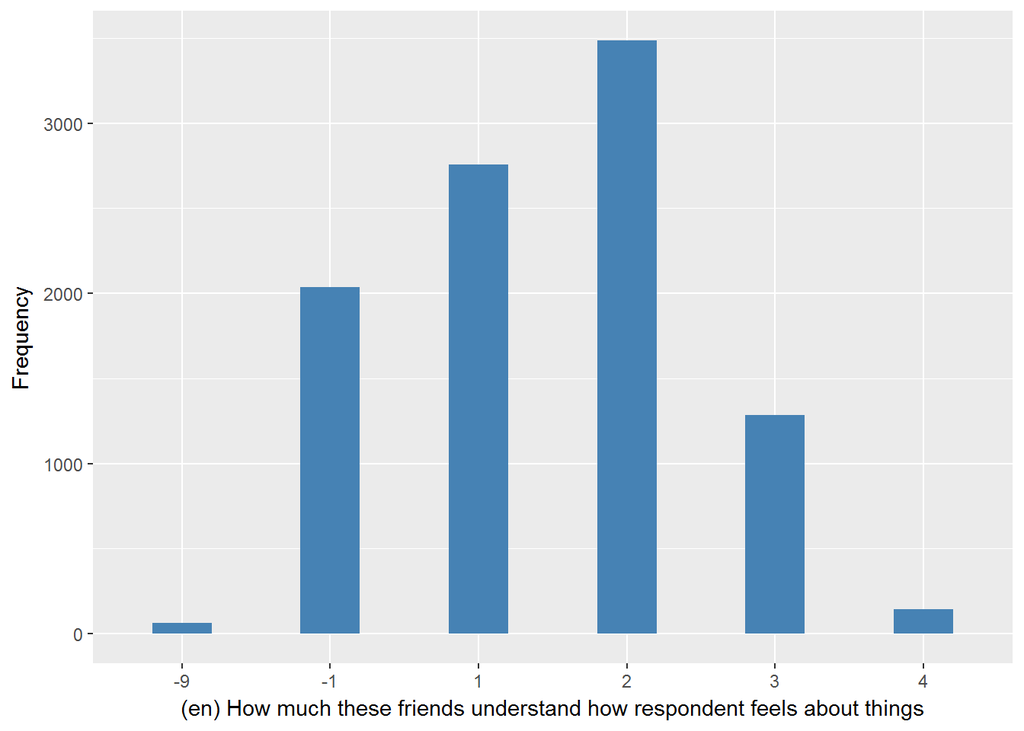

scfrdb

| Sample size | Missing values |
| --- | --- |
| 9771 | 2098 |

Category

|  | 1 | 2 | 3 | 4 |
| --- | --- | --- | --- | --- |
| Frequency | 4192.0 | 2339.00 | 972.00 | 170.00 |
| Percentage | 42.9 | 23.94 | 9.95 | 1.74 |

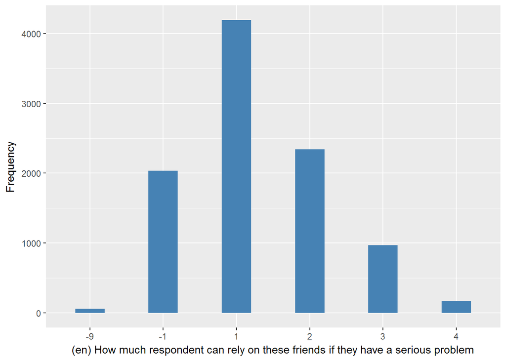

scfrdc

| Sample size | Missing values |
| --- | --- |
| 9771 | 2106 |

Category

|  | 1 | 2 | 3 | 4 |
| --- | --- | --- | --- | --- |
| Frequency | 3137.00 | 2711.00 | 1468.00 | 349.00 |
| Percentage | 32.11 | 27.75 | 15.02 | 3.57 |

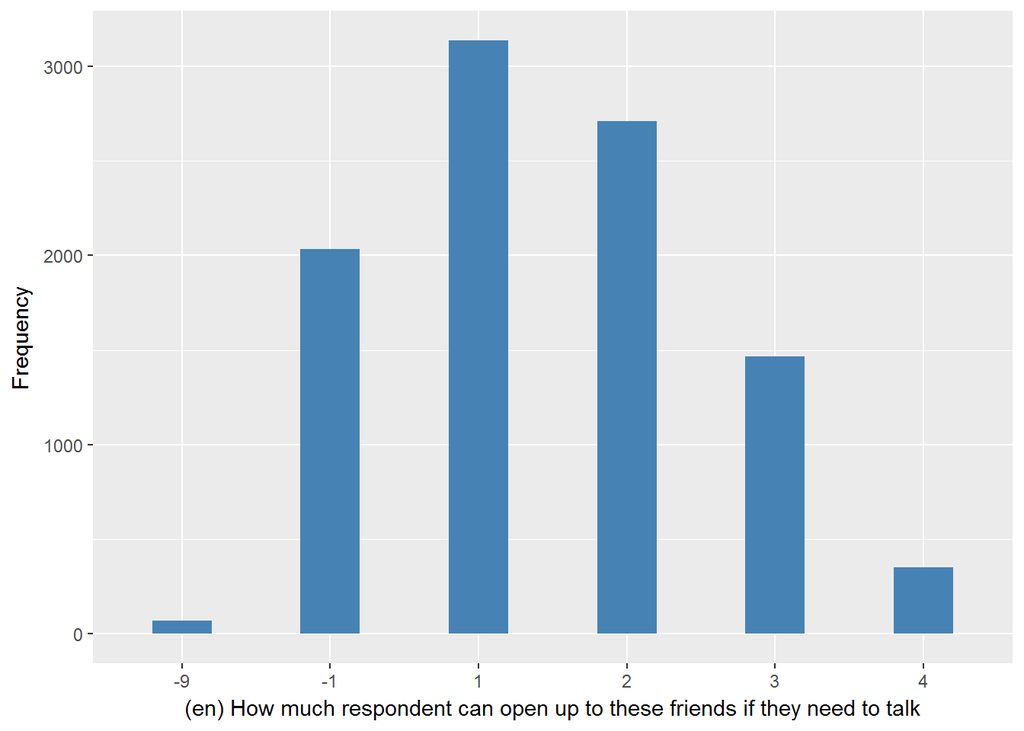

#### 2.1.3.2 Harmonisation algorithm

To compute the harmonize variable from the study-specific variable it has to be recoded as follows:

- `if any variable equals 1 or 2 then 1`
- `if all are equal 3 or 4 then 0`
- `-1 into 996`
- `-8 into 998`
- `-9 into 995`
- `NA into 999`

**R script:**

```r
ELSA_ds_w3 <- tibble(id = ELSA_w3_emot_sup$id)

ELSA_w3_emot_sup$scptra <- car::recode(as.vector(ELSA_w3_emot_sup$scptra), "NA='-999'")
ELSA_w3_emot_sup$scptrb <- car::recode(as.vector(ELSA_w3_emot_sup$scptrb), "NA='-999'")
ELSA_w3_emot_sup$scptrc <- car::recode(as.vector(ELSA_w3_emot_sup$scptrc), "NA='-999'")
ELSA_w3_emot_sup$scchda <- car::recode(as.vector(ELSA_w3_emot_sup$scchda), "NA='-999'")
ELSA_w3_emot_sup$scchdb <- car::recode(as.vector(ELSA_w3_emot_sup$scchdb), "NA='-999'")
ELSA_w3_emot_sup$scchdc <- car::recode(as.vector(ELSA_w3_emot_sup$scchdc), "NA='-999'")
ELSA_w3_emot_sup$scfama <- car::recode(as.vector(ELSA_w3_emot_sup$scfama), "NA='-999'")
ELSA_w3_emot_sup$scfamb <- car::recode(as.vector(ELSA_w3_emot_sup$scfamb), "NA='-999'")
ELSA_w3_emot_sup$scfamc <- car::recode(as.vector(ELSA_w3_emot_sup$scfamc), "NA='-999'")
ELSA_w3_emot_sup$scfrda <- car::recode(as.vector(ELSA_w3_emot_sup$scfrda), "NA='-999'")
ELSA_w3_emot_sup$scfrdb <- car::recode(as.vector(ELSA_w3_emot_sup$scfrdb), "NA='-999'")
ELSA_w3_emot_sup$scfrdc <- car::recode(as.vector(ELSA_w3_emot_sup$scfrdc), "NA='-999'")


ELSA_ds_w3$emot_sup <- c(NA)
for (i in 1:dim(ELSA_w3_emot_sup)[1]) {
    if (ELSA_w3_emot_sup$scptra[i] %in% c(1, 2) | ELSA_w3_emot_sup$scptrb[i] %in%
        c(1, 2) | ELSA_w3_emot_sup$scptrc[i] %in% c(1, 2) | ELSA_w3_emot_sup$scchda[i] %in%
        c(1, 2) | ELSA_w3_emot_sup$scchdb[i] %in% c(1, 2) | ELSA_w3_emot_sup$scchdc[i] %in%
        c(1, 2) | ELSA_w3_emot_sup$scfama[i] %in% c(1, 2) | ELSA_w3_emot_sup$scfamb[i] %in%
        c(1, 2) | ELSA_w3_emot_sup$scfamc[i] %in% c(1, 2) | ELSA_w3_emot_sup$scfrda[i] %in%
        c(1, 2) | ELSA_w3_emot_sup$scfrdb[i] %in% c(1, 2) | ELSA_w3_emot_sup$scfrdc[i] %in%
        c(1, 2)) {
        ELSA_ds_w3$emot_sup[i] = 1
    } else if (ELSA_w3_emot_sup$scptra[i] %in% c(3, 4, -1) & ELSA_w3_emot_sup$scptrb[i] %in%
        c(3, 4, -1) & ELSA_w3_emot_sup$scptrc[i] %in% c(3, 4, -1) & ELSA_w3_emot_sup$scchda[i] %in%
        c(3, 4, -1) & ELSA_w3_emot_sup$scchdb[i] %in% c(3, 4, -1) & ELSA_w3_emot_sup$scchdc[i] %in%
        c(3, 4, -1) & ELSA_w3_emot_sup$scfama[i] %in% c(3, 4, -1) & ELSA_w3_emot_sup$scfamb[i] %in%
        c(3, 4, -1) & ELSA_w3_emot_sup$scfamc[i] %in% c(3, 4, -1) & ELSA_w3_emot_sup$scfrda[i] %in%
        c(3, 4, -1) & ELSA_w3_emot_sup$scfrdb[i] %in% c(3, 4, -1) & ELSA_w3_emot_sup$scfrdc[i] %in%
        c(3, 4, -1)) {
        ELSA_ds_w3$emot_sup[i] = 0
    } else if (ELSA_w3_emot_sup$scptra[i] == -1 | ELSA_w3_emot_sup$scptrb[i] ==
        -1 | ELSA_w3_emot_sup$scptrc[i] == -1 | ELSA_w3_emot_sup$scchda[i] ==
        -1 | ELSA_w3_emot_sup$scchdb[i] == -1 | ELSA_w3_emot_sup$scchdc[i] ==
        -1 | ELSA_w3_emot_sup$scfama[i] == -1 | ELSA_w3_emot_sup$scfamb[i] ==
        -1 | ELSA_w3_emot_sup$scfamc[i] == -1 | ELSA_w3_emot_sup$scfrda[i] ==
        -1 | ELSA_w3_emot_sup$scfrdb[i] == -1 | ELSA_w3_emot_sup$scfrdc[i] ==
        -1) {
        ELSA_ds_w3$emot_sup[i] = 996
    } else if (ELSA_w3_emot_sup$scptra[i] == -9 | ELSA_w3_emot_sup$scptrb[i] ==
        -9 | ELSA_w3_emot_sup$scptrc[i] == -9 | ELSA_w3_emot_sup$scchda[i] ==
        -9 | ELSA_w3_emot_sup$scchdb[i] == -9 | ELSA_w3_emot_sup$scchdc[i] ==
        -9 | ELSA_w3_emot_sup$scfama[i] == -9 | ELSA_w3_emot_sup$scfamb[i] ==
        -9 | ELSA_w3_emot_sup$scfamc[i] == -9 | ELSA_w3_emot_sup$scfrda[i] ==
        -9 | ELSA_w3_emot_sup$scfrdb[i] == -9 | ELSA_w3_emot_sup$scfrdc[i] ==
        -9) {
        ELSA_ds_w3$emot_sup[i] = 995
    } else if (ELSA_w3_emot_sup$scptra[i] == -8 | ELSA_w3_emot_sup$scptrb[i] ==
        -8 | ELSA_w3_emot_sup$scptrc[i] == -8 | ELSA_w3_emot_sup$scchda[i] ==
        -8 | ELSA_w3_emot_sup$scchdb[i] == -8 | ELSA_w3_emot_sup$scchdc[i] ==
        -8 | ELSA_w3_emot_sup$scfama[i] == -8 | ELSA_w3_emot_sup$scfamb[i] ==
        -8 | ELSA_w3_emot_sup$scfamc[i] == -8 | ELSA_w3_emot_sup$scfrda[i] ==
        -8 | ELSA_w3_emot_sup$scfrdb[i] == -8 | ELSA_w3_emot_sup$scfrdc[i] ==
        -8) {
        ELSA_ds_w3$emot_sup[i] = 998
    }
}

ELSA_ds_w3$emot_sup <- car::recode(as.vector(ELSA_ds_w3$emot_sup), "NA='999'")
ELSA_ds_w3$emot_sup <- labelled(ELSA_ds_w3$emot_sup, labels = c(No = 0, Yes = 1,
    Missing = 999, `Do not know` = 998, Refuse = 997, `Not applicable` = 996,
    `Don't answer` = 995, `Not attempt/not done/not yet recorded` = 994, `Disable to measure` = 993,
    Impute = 992, `CAPI/interviewer error` = 991))
```

#### 2.1.3.3 Statistics of the new harmonised variable

Receives emotional support from someone

| Sample size | Missing values |
| --- | --- |
| 9771 | 12 |

Category

|  | 0 | 1 |
| --- | --- | --- |
| Frequency | 1589.00 | 8170.00 |
| Percentage | 16.26 | 83.61 |

Type of missing

|  | 991 | 992 | 993 | 994 | 995 | 996 | 997 | 998 | 999 | NA |
| --- | --- | --- | --- | --- | --- | --- | --- | --- | --- | --- |
| Frequency | 0 | 0 | 0 | 0 | 1.00 | 11.00 | 0 | 0 | 0 | 0 |
| Percentage | 0 | 0 | 0 | 0 | 0.01 | 0.11 | 0 | 0 | 0 | 0 |

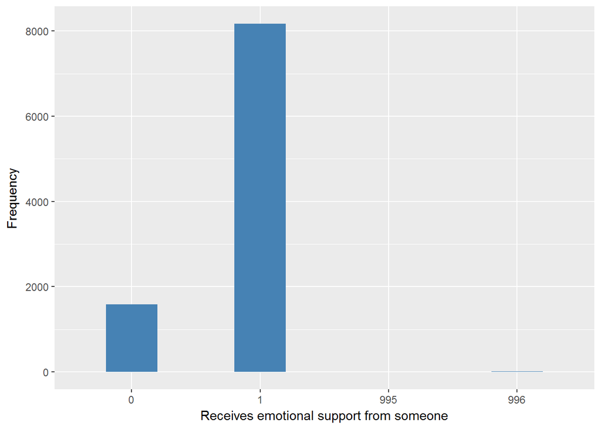

#### 2.1.3.4 Validation

### 2.1.4 Wave 4

#### 2.1.4.1 Study-specific variable description

| **Name** | `scptra` | `scptrb` | `scptrc` | `scchda` | `scchdb` | `scchdc` | `scfama` | `scfamb` | `scfamc` | `scfrda` | `scfrdb` | `scfrdc` |
| --- | --- | --- | --- | --- | --- | --- | --- | --- | --- | --- | --- | --- |
| **Label** | `how much does your spouse/partner really understand the way you feel?` | `how much can you rely on your spouse/partner if you have a serious problem?` | `how much can you open up to your spouse/partner if you need to talk about your worries?` | `how much do your children really understand the way you feel about things?` | `how much can you rely on your children if you have a serious problem?` | `how much can you open up to your children if you need to talk about your worries?` | `how much do these family members really understand the way you feel?` | `how much can you rely on these family members if you have a serious problem?` | `how much can you open up to these family members if you need to talk about your worries?` | `how much do your friends really understand the way you feel about things?` | `how much can you rely on these friends if you have a serious problem?` | `how much can you open up to these friends if you need to talk about your worries?` |
| **Table name** | `wave_4_elsa_data_v3` | `wave_4_elsa_data_v3` | `wave_4_elsa_data_v3` | `wave_4_elsa_data_v3` | `wave_4_elsa_data_v3` | `wave_4_elsa_data_v3` | `wave_4_elsa_data_v3` | `wave_4_elsa_data_v3` | `wave_4_elsa_data_v3` | `wave_4_elsa_data_v3` | `wave_4_elsa_data_v3` | `wave_4_elsa_data_v3` |
| **Categories** | `1 = A lot` `2 = Some` `3 = A little` `4 = Not at all` | `1 = A lot` `2 = Some` `3 = A little` `4 = Not at all` | `1 = A lot` `2 = Some` `3 = A little` `4 = Not at all` | `1 = A lot` `2 = Some` `3 = A little` `4 = Not at all` | `1 = A lot` `2 = Some` `3 = A little` `4 = Not at all` | `1 = A lot` `2 = Some` `3 = A little` `4 = Not at all` | `1 = A lot` `2 = Some` `3 = A little` `4 = Not at all` | `1 = A lot` `2 = Some` `3 = A little` `4 = Not at all` | `1 = A lot` `2 = Some` `3 = A little` `4 = Not at all` | `1 = A lot` `2 = Some` `3 = A little` `4 = Not at all` | `1 = A lot` `2 = Some` `3 = A little` `4 = Not at all` | `1 = A lot` `2 = Some` `3 = A little` `4 = Not at all` |
| **Missings** | `-9 = Not answered` `-1 = Item not applicable` `-8 = Don't know` | `-9 = Not answered` `-8 = Don't know` `-1 = Item not applicable` | `-9 = Not answered` `-8 = Don't know` `-1 = Item not applicable` | `-9 = Not answered` `-8 = Don't know` `-1 = Item not applicable` | `-9 = Not answered` `-8 = Don't know` `-1 = Item not applicable` | `-9 = Not answered` `-8 = Don't know` `-1 = Item not applicable` | `-9 = Not answered` `-8 = Don't know` `-1 = Item not applicable` | `-9 = Not answered` `-8 = Don't know` `-1 = Item not applicable` | `-9 = Not answered` `-8 = Don't know` `-1 = Item not applicable` | `-9 = Not answered` `-8 = Don't know` `-1 = Item not applicable` | `-9 = Not answered` `-8 = Don't know` `-1 = Item not applicable` | `-9 = Not answered` `-8 = Don't know` `-1 = Item not applicable` |
| **Description** |  |  |  |  |  |  |  |  |  |  |  |  |

scptra

| Sample size | Missing values |
| --- | --- |
| 11050 | 4287 |

Category

|  | 1 | 2 | 3 | 4 |
| --- | --- | --- | --- | --- |
| Frequency | 3823.0 | 2292.00 | 525.00 | 123.00 |
| Percentage | 34.6 | 20.74 | 4.75 | 1.11 |

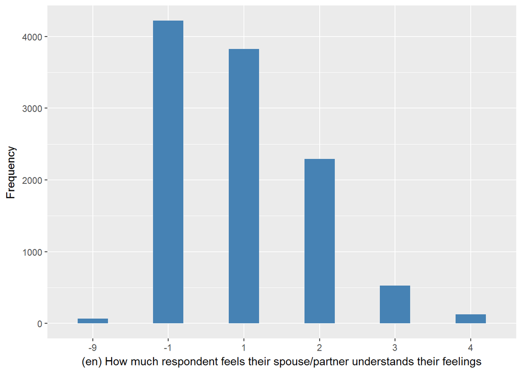

scptrb

| Sample size | Missing values |
| --- | --- |
| 11050 | 4271 |

Category

|  | 1 | 2 | 3 | 4 |
| --- | --- | --- | --- | --- |
| Frequency | 6028.00 | 490.00 | 191.00 | 70.00 |
| Percentage | 54.55 | 4.43 | 1.73 | 0.63 |

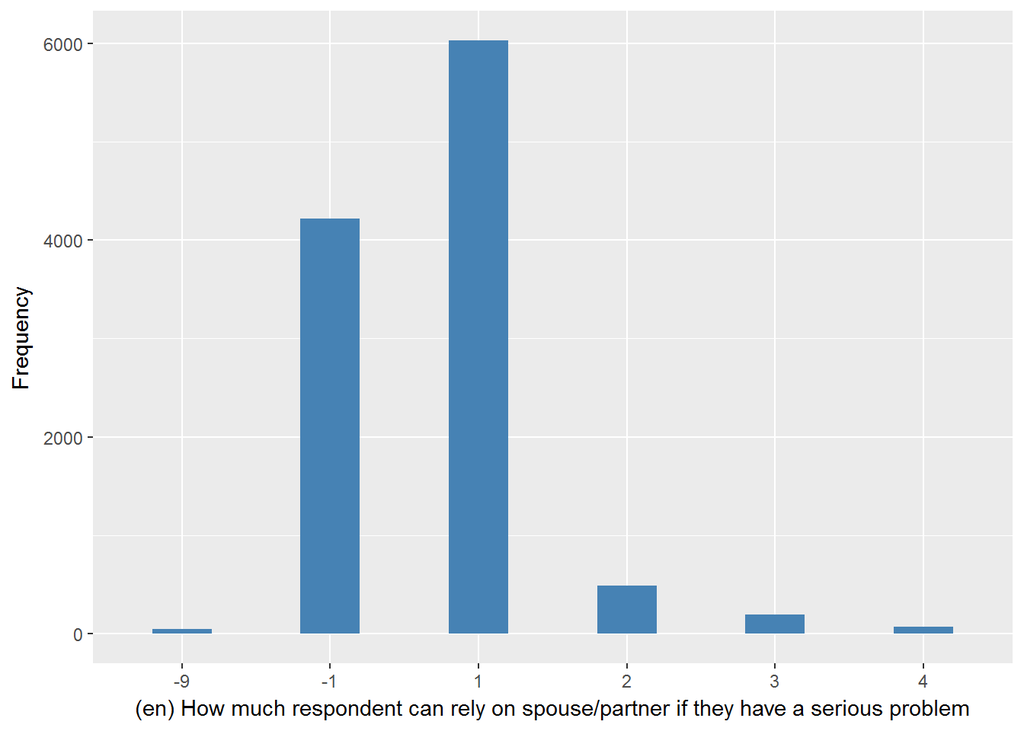

scptrc

| Sample size | Missing values |
| --- | --- |
| 11050 | 4273 |

Category

|  | 1 | 2 | 3 | 4 |
| --- | --- | --- | --- | --- |
| Frequency | 4595.00 | 1580.0 | 448.00 | 154.00 |
| Percentage | 41.58 | 14.3 | 4.05 | 1.39 |

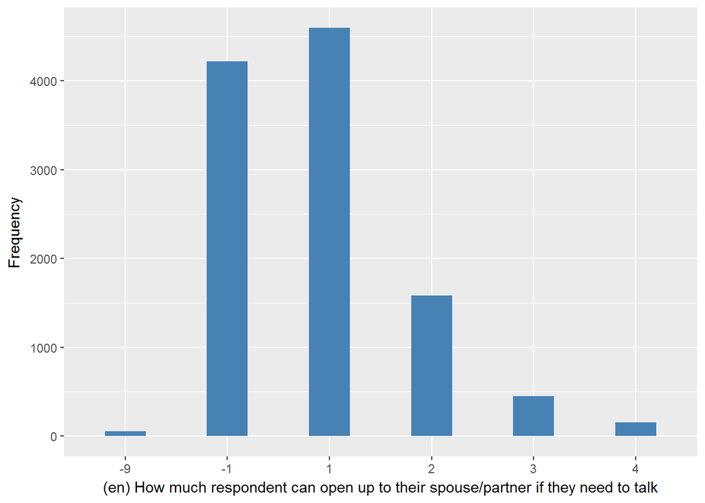

scchda

| Sample size | Missing values |
| --- | --- |
| 11050 | 3171 |

Category

|  | 1 | 2 | 3 | 4 |
| --- | --- | --- | --- | --- |
| Frequency | 3098.00 | 3389.00 | 1116.0 | 276.0 |
| Percentage | 28.04 | 30.67 | 10.1 | 2.5 |

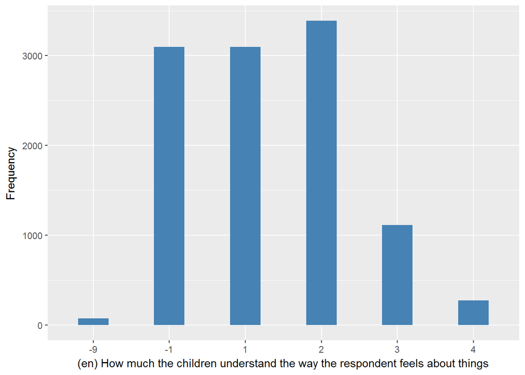

scchdb

| Sample size | Missing values |
| --- | --- |
| 11050 | 3156 |

Category

|  | 1 | 2 | 3 | 4 |
| --- | --- | --- | --- | --- |
| Frequency | 5802.00 | 1293.0 | 555.00 | 244.00 |
| Percentage | 52.51 | 11.7 | 5.02 | 2.21 |

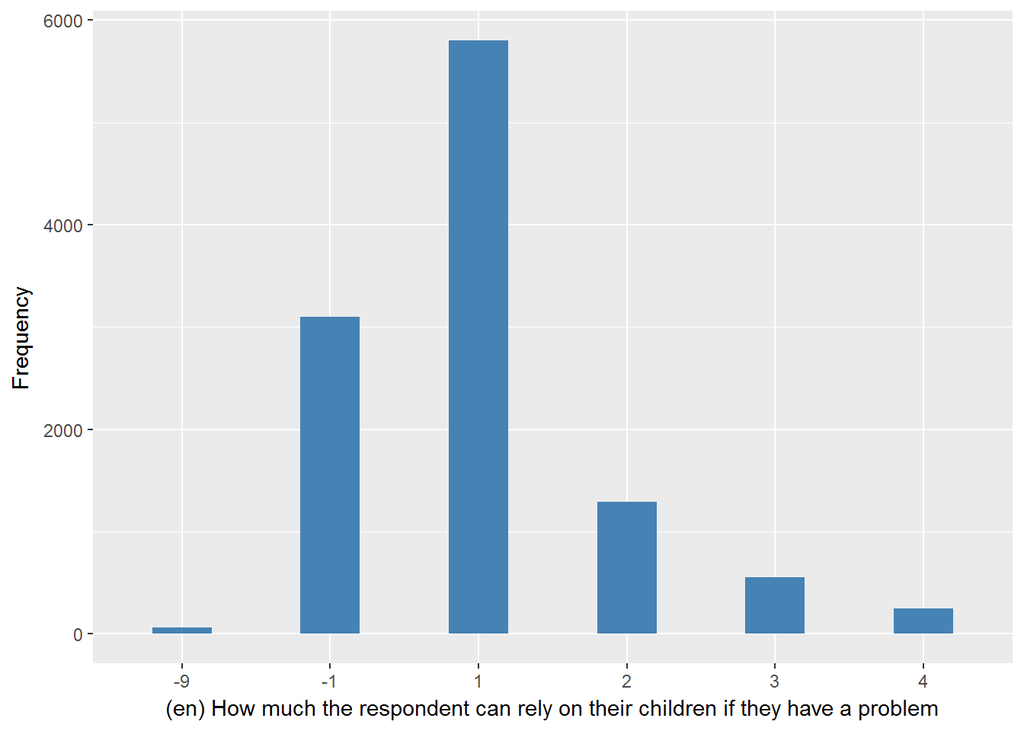

scchdc

| Sample size | Missing values |
| --- | --- |
| 11050 | 3167 |

Category

|  | 1 | 2 | 3 | 4 |
| --- | --- | --- | --- | --- |
| Frequency | 3646 | 2642.00 | 1202.00 | 393.00 |
| Percentage | 33 | 23.91 | 10.88 | 3.56 |

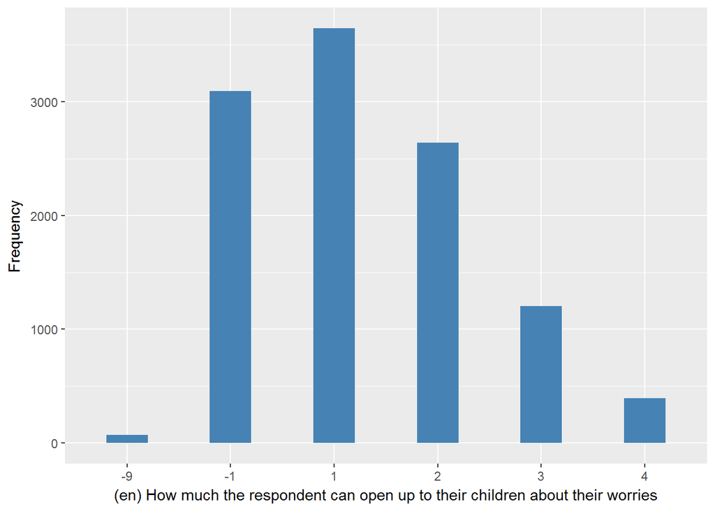

scfama

| Sample size | Missing values |
| --- | --- |
| 11050 | 2664 |

Category

|  | 1 | 2 | 3 | 4 |
| --- | --- | --- | --- | --- |
| Frequency | 1737.00 | 3401.00 | 2219.00 | 1029.00 |
| Percentage | 15.72 | 30.78 | 20.08 | 9.31 |

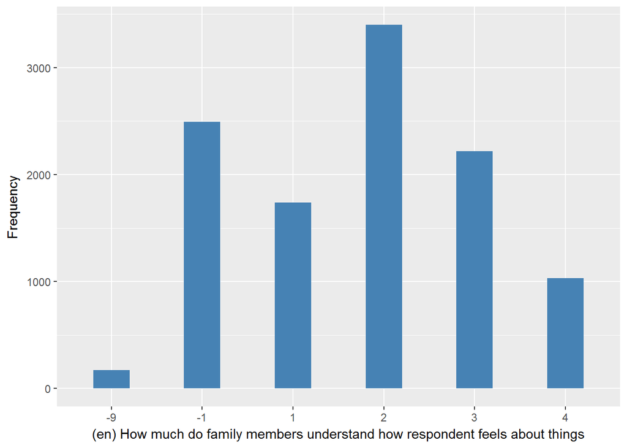

scfamb

| Sample size | Missing values |
| --- | --- |
| 11050 | 2649 |

Category

|  | 1 | 2 | 3 | 4 |
| --- | --- | --- | --- | --- |
| Frequency | 3845.0 | 2123.00 | 1409.00 | 1024.00 |
| Percentage | 34.8 | 19.21 | 12.75 | 9.27 |

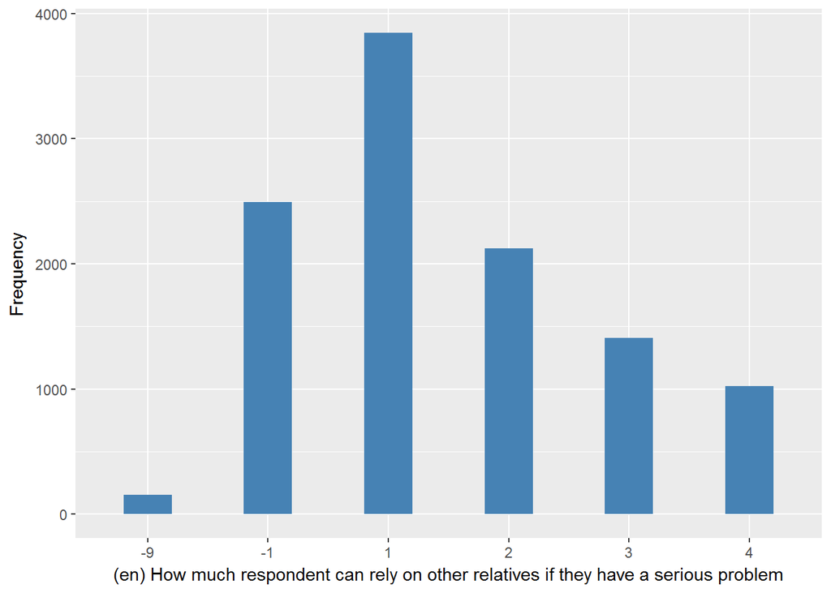

scfamc

| Sample size | Missing values |
| --- | --- |
| 11050 | 2660 |

Category

|  | 1 | 2 | 3 | 4 |
| --- | --- | --- | --- | --- |
| Frequency | 2401.00 | 2598.00 | 1977.00 | 1414.0 |
| Percentage | 21.73 | 23.51 | 17.89 | 12.8 |

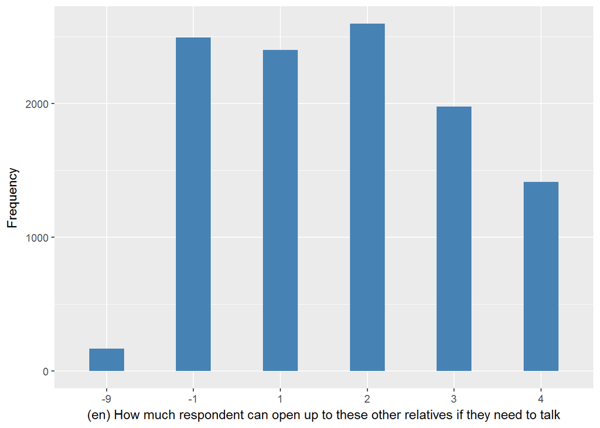

scfrda

| Sample size | Missing values |
| --- | --- |
| 11050 | 2370 |

Category

|  | 1 | 2 | 3 | 4 |
| --- | --- | --- | --- | --- |
| Frequency | 2987.00 | 3944.00 | 1580.0 | 169.00 |
| Percentage | 27.03 | 35.69 | 14.3 | 1.53 |

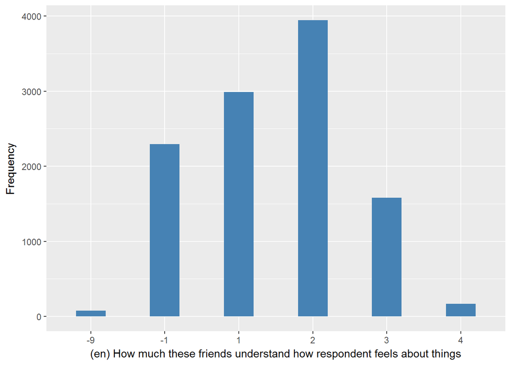

scfrdb

| Sample size | Missing values |
| --- | --- |
| 11050 | 2374 |

Category

|  | 1 | 2 | 3 | 4 |
| --- | --- | --- | --- | --- |
| Frequency | 4375.00 | 2812.00 | 1248.00 | 241.00 |
| Percentage | 39.59 | 25.45 | 11.29 | 2.18 |

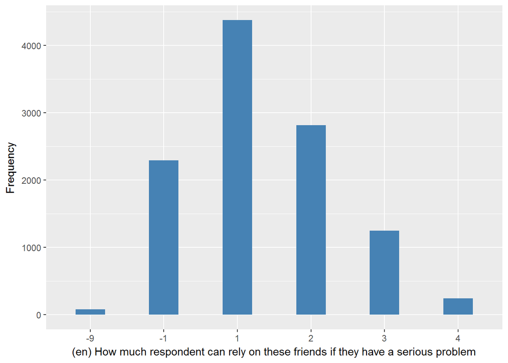

scfrdc

| Sample size | Missing values |
| --- | --- |
| 11050 | 2372 |

Category

|  | 1 | 2 | 3 | 4 |
| --- | --- | --- | --- | --- |
| Frequency | 3284.00 | 3130.00 | 1836.00 | 428.00 |
| Percentage | 29.72 | 28.33 | 16.62 | 3.87 |

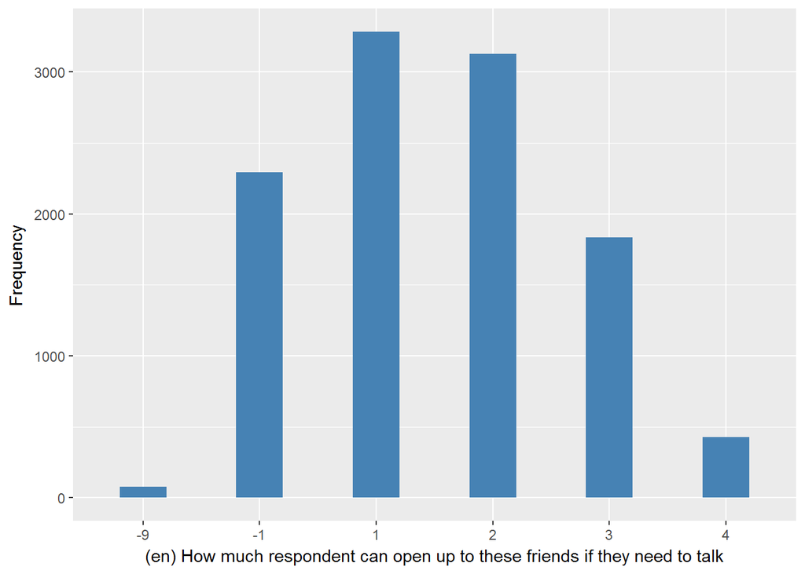

#### 2.1.4.2 Harmonisation algorithm

To compute the harmonize variable from the study-specific variable it has to be recoded as follows:

- `if any variable equals 1 or 2 then 1`
- `if all are equal 3 or 4 then 0`
- `-1 into 996`
- `-8 into 998`
- `-9 into 995`
- `NA into 999`

**R script:**

```r
ELSA_ds_w4 <- tibble(id = ELSA_w4_emot_sup$id)

ELSA_w4_emot_sup$scptra <- car::recode(as.vector(ELSA_w4_emot_sup$scptra), "NA='-999'")
ELSA_w4_emot_sup$scptrb <- car::recode(as.vector(ELSA_w4_emot_sup$scptrb), "NA='-999'")
ELSA_w4_emot_sup$scptrc <- car::recode(as.vector(ELSA_w4_emot_sup$scptrc), "NA='-999'")
ELSA_w4_emot_sup$scchda <- car::recode(as.vector(ELSA_w4_emot_sup$scchda), "NA='-999'")
ELSA_w4_emot_sup$scchdb <- car::recode(as.vector(ELSA_w4_emot_sup$scchdb), "NA='-999'")
ELSA_w4_emot_sup$scchdc <- car::recode(as.vector(ELSA_w4_emot_sup$scchdc), "NA='-999'")
ELSA_w4_emot_sup$scfama <- car::recode(as.vector(ELSA_w4_emot_sup$scfama), "NA='-999'")
ELSA_w4_emot_sup$scfamb <- car::recode(as.vector(ELSA_w4_emot_sup$scfamb), "NA='-999'")
ELSA_w4_emot_sup$scfamc <- car::recode(as.vector(ELSA_w4_emot_sup$scfamc), "NA='-999'")
ELSA_w4_emot_sup$scfrda <- car::recode(as.vector(ELSA_w4_emot_sup$scfrda), "NA='-999'")
ELSA_w4_emot_sup$scfrdb <- car::recode(as.vector(ELSA_w4_emot_sup$scfrdb), "NA='-999'")
ELSA_w4_emot_sup$scfrdc <- car::recode(as.vector(ELSA_w4_emot_sup$scfrdc), "NA='-999'")


ELSA_ds_w4$emot_sup <- c(NA)
for (i in 1:dim(ELSA_w4_emot_sup)[1]) {
    if (ELSA_w4_emot_sup$scptra[i] %in% c(1, 2) | ELSA_w4_emot_sup$scptrb[i] %in%
        c(1, 2) | ELSA_w4_emot_sup$scptrc[i] %in% c(1, 2) | ELSA_w4_emot_sup$scchda[i] %in%
        c(1, 2) | ELSA_w4_emot_sup$scchdb[i] %in% c(1, 2) | ELSA_w4_emot_sup$scchdc[i] %in%
        c(1, 2) | ELSA_w4_emot_sup$scfama[i] %in% c(1, 2) | ELSA_w4_emot_sup$scfamb[i] %in%
        c(1, 2) | ELSA_w4_emot_sup$scfamc[i] %in% c(1, 2) | ELSA_w4_emot_sup$scfrda[i] %in%
        c(1, 2) | ELSA_w4_emot_sup$scfrdb[i] %in% c(1, 2) | ELSA_w4_emot_sup$scfrdc[i] %in%
        c(1, 2)) {
        ELSA_ds_w4$emot_sup[i] = 1
    } else if (ELSA_w4_emot_sup$scptra[i] %in% c(3, 4, -1) & ELSA_w4_emot_sup$scptrb[i] %in%
        c(3, 4, -1) & ELSA_w4_emot_sup$scptrc[i] %in% c(3, 4, -1) & ELSA_w4_emot_sup$scchda[i] %in%
        c(3, 4, -1) & ELSA_w4_emot_sup$scchdb[i] %in% c(3, 4, -1) & ELSA_w4_emot_sup$scchdc[i] %in%
        c(3, 4, -1) & ELSA_w4_emot_sup$scfama[i] %in% c(3, 4, -1) & ELSA_w4_emot_sup$scfamb[i] %in%
        c(3, 4, -1) & ELSA_w4_emot_sup$scfamc[i] %in% c(3, 4, -1) & ELSA_w4_emot_sup$scfrda[i] %in%
        c(3, 4, -1) & ELSA_w4_emot_sup$scfrdb[i] %in% c(3, 4, -1) & ELSA_w4_emot_sup$scfrdc[i] %in%
        c(3, 4, -1)) {
        ELSA_ds_w4$emot_sup[i] = 0
    } else if (ELSA_w4_emot_sup$scptra[i] == -1 | ELSA_w4_emot_sup$scptrb[i] ==
        -1 | ELSA_w4_emot_sup$scptrc[i] == -1 | ELSA_w4_emot_sup$scchda[i] ==
        -1 | ELSA_w4_emot_sup$scchdb[i] == -1 | ELSA_w4_emot_sup$scchdc[i] ==
        -1 | ELSA_w4_emot_sup$scfama[i] == -1 | ELSA_w4_emot_sup$scfamb[i] ==
        -1 | ELSA_w4_emot_sup$scfamc[i] == -1 | ELSA_w4_emot_sup$scfrda[i] ==
        -1 | ELSA_w4_emot_sup$scfrdb[i] == -1 | ELSA_w4_emot_sup$scfrdc[i] ==
        -1) {
        ELSA_ds_w4$emot_sup[i] = 996
    } else if (ELSA_w4_emot_sup$scptra[i] == -9 | ELSA_w4_emot_sup$scptrb[i] ==
        -9 | ELSA_w4_emot_sup$scptrc[i] == -9 | ELSA_w4_emot_sup$scchda[i] ==
        -9 | ELSA_w4_emot_sup$scchdb[i] == -9 | ELSA_w4_emot_sup$scchdc[i] ==
        -9 | ELSA_w4_emot_sup$scfama[i] == -9 | ELSA_w4_emot_sup$scfamb[i] ==
        -9 | ELSA_w4_emot_sup$scfamc[i] == -9 | ELSA_w4_emot_sup$scfrda[i] ==
        -9 | ELSA_w4_emot_sup$scfrdb[i] == -9 | ELSA_w4_emot_sup$scfrdc[i] ==
        -9) {
        ELSA_ds_w4$emot_sup[i] = 995
    } else if (ELSA_w4_emot_sup$scptra[i] == -8 | ELSA_w4_emot_sup$scptrb[i] ==
        -8 | ELSA_w4_emot_sup$scptrc[i] == -8 | ELSA_w4_emot_sup$scchda[i] ==
        -8 | ELSA_w4_emot_sup$scchdb[i] == -8 | ELSA_w4_emot_sup$scchdc[i] ==
        -8 | ELSA_w4_emot_sup$scfama[i] == -8 | ELSA_w4_emot_sup$scfamb[i] ==
        -8 | ELSA_w4_emot_sup$scfamc[i] == -8 | ELSA_w4_emot_sup$scfrda[i] ==
        -8 | ELSA_w4_emot_sup$scfrdb[i] == -8 | ELSA_w4_emot_sup$scfrdc[i] ==
        -8) {
        ELSA_ds_w4$emot_sup[i] = 998
    }
}

ELSA_ds_w4$emot_sup <- car::recode(as.vector(ELSA_ds_w4$emot_sup), "NA='999'")
ELSA_ds_w4$emot_sup <- labelled(ELSA_ds_w4$emot_sup, labels = c(No = 0, Yes = 1,
    Missing = 999, `Do not know` = 998, Refuse = 997, `Not applicable` = 996,
    `Don't answer` = 995, `Not attempt/not done/not yet recorded` = 994, `Disable to measure` = 993,
    Impute = 992, `CAPI/interviewer error` = 991))
```

#### 2.1.4.3 Statistics of the new harmonised variable

Receives emotional support from someone

| Sample size | Missing values |
| --- | --- |
| 11050 | 19 |

Category

|  | 0 | 1 |
| --- | --- | --- |
| Frequency | 1781.00 | 9250.00 |
| Percentage | 16.12 | 83.71 |

Type of missing

|  | 991 | 992 | 993 | 994 | 995 | 996 | 997 | 998 | 999 | NA |
| --- | --- | --- | --- | --- | --- | --- | --- | --- | --- | --- |
| Frequency | 0 | 0 | 0 | 0 | 3.00 | 16.00 | 0 | 0 | 0 | 0 |
| Percentage | 0 | 0 | 0 | 0 | 0.03 | 0.14 | 0 | 0 | 0 | 0 |

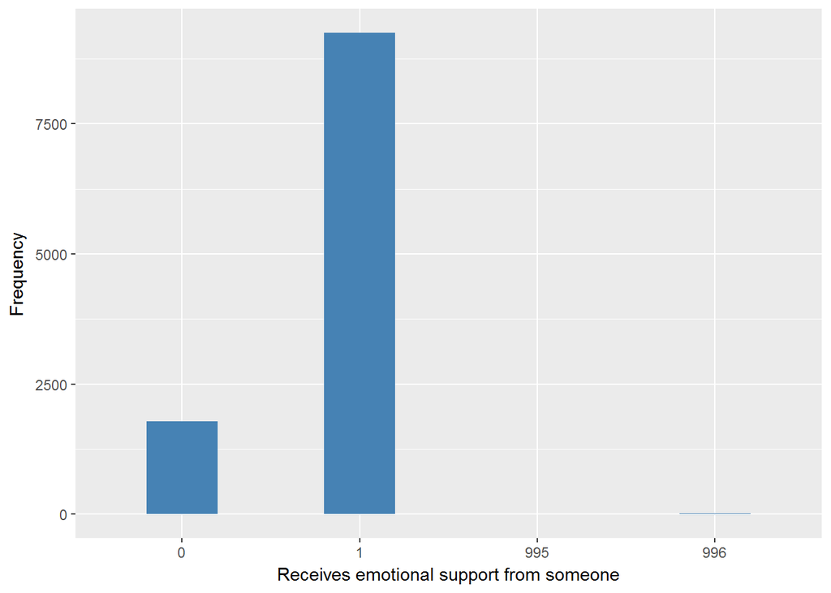

#### 2.1.4.4 Validation

### 2.1.5 Wave 5

#### 2.1.5.1 Study-specific variable description

| **Name** | `scptra` | `scptrb` | `scptrc` | `scchda` | `scchdb` | `scchdc` | `scfama` | `scfamb` | `scfamc` | `scfrda` | `scfrdb` | `scfrdc` |
| --- | --- | --- | --- | --- | --- | --- | --- | --- | --- | --- | --- | --- |
| **Label** | `how much does your spouse/partner really understand the way you feel?` | `how much can you rely on your spouse/partner if you have a serious problem?` | `how much can you open up to your spouse/partner if you need to talk about your worries?` | `how much do your children really understand the way you feel about things?` | `how much can you rely on your children if you have a serious problem?` | `how much can you open up to your children if you need to talk about your worries?` | `how much do these family members really understand the way you feel?` | `how much can you rely on these family members if you have a serious problem?` | `how much can you open up to these family members if you need to talk about your worries?` | `how much do your friends really understand the way you feel about things?` | `how much can you rely on these friends if you have a serious problem?` | `how much can you open up to these friends if you need to talk about your worries?` |
| **Table name** | `wave_5_elsa_data_v4` | `wave_5_elsa_data_v4` | `wave_5_elsa_data_v4` | `wave_5_elsa_data_v4` | `wave_5_elsa_data_v4` | `wave_5_elsa_data_v4` | `wave_5_elsa_data_v4` | `wave_5_elsa_data_v4` | `wave_5_elsa_data_v4` | `wave_5_elsa_data_v4` | `wave_5_elsa_data_v4` | `wave_5_elsa_data_v4` |
| **Categories** | `1 = A lot` `2 = Some` `3 = A little` `4 = Not at all` | `1 = A lot` `2 = Some` `3 = A little` `4 = Not at all` | `1 = A lot` `2 = Some` `3 = A little` `4 = Not at all` | `1 = A lot` `2 = Some` `3 = A little` `4 = Not at all` | `1 = A lot` `2 = Some` `3 = A little` `4 = Not at all` | `1 = A lot` `2 = Some` `3 = A little` `4 = Not at all` | `1 = A lot` `2 = Some` `3 = A little` `4 = Not at all` | `1 = A lot` `2 = Some` `3 = A little` `4 = Not at all` | `1 = A lot` `2 = Some` `3 = A little` `4 = Not at all` | `1 = A lot` `2 = Some` `3 = A little` `4 = Not at all` | `1 = A lot` `2 = Some` `3 = A little` `4 = Not at all` | `1 = A lot` `2 = Some` `3 = A little` `4 = Not at all` |
| **Missings** | `-9 = Not answered` `-1 = Item not applicable` `-8 = Don't know` `-2 = Schedule Not Applicable` | `-9 = Not answered` `-8 = Don't know` `-2 = Schedule Not Applicable` `-1 = Item not applicable` | `-9 = Not answered` `-8 = Don't know` `-2 = Schedule Not Applicable` `-1 = Item not applicable` | `-9 = Not answered` `-8 = Don't know` `-2 = Schedule Not Applicable` `-1 = Item not applicable` | `-9 = Not answered` `-8 = Don't know` `-2 = Schedule Not Applicable` `-1 = Item not applicable` | `-9 = Not answered` `-8 = Don't know` `-2 = Schedule Not Applicable` `-1 = Item not applicable` | `-9 = Not answered` `-8 = Don't know` `-2 = Schedule Not Applicable` `-1 = Item not applicable` | `-9 = Not answered` `-8 = Don't know` `-2 = Schedule Not Applicable` `-1 = Item not applicable` | `-9 = Not answered` `-8 = Don't know` `-2 = Schedule Not Applicable` `-1 = Item not applicable` | `-9 = Not answered` `-8 = Don't know` `-2 = Schedule Not Applicable` `-1 = Item not applicable` | `-9 = Not answered` `-8 = Don't know` `-2 = Schedule Not Applicable` `-1 = Item not applicable` | `-9 = Not answered` `-8 = Don't know` `-2 = Schedule Not Applicable` `-1 = Item not applicable` |
| **Description** |  |  |  |  |  |  |  |  |  |  |  |  |

scptra

| Sample size | Missing values |
| --- | --- |
| 10274 | 3845 |

Category

|  | 1 | 2 | 3 | 4 |
| --- | --- | --- | --- | --- |
| Frequency | 3386.00 | 2381.00 | 552.00 | 110.00 |
| Percentage | 32.96 | 23.18 | 5.37 | 1.07 |

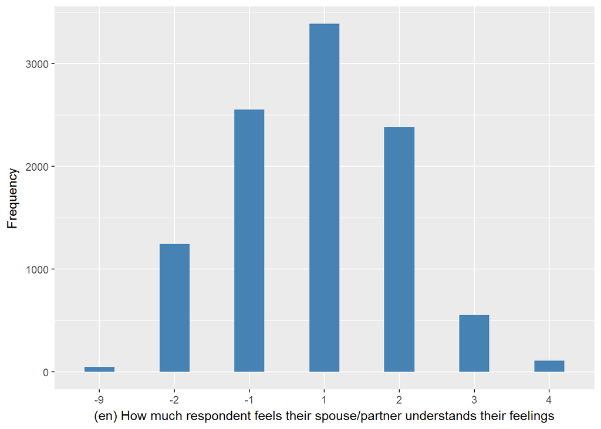

scptrb

| Sample size | Missing values |
| --- | --- |
| 10274 | 3835 |

Category

|  | 1 | 2 | 3 | 4 |
| --- | --- | --- | --- | --- |
| Frequency | 5612.00 | 546.00 | 217.00 | 64.00 |
| Percentage | 54.62 | 5.31 | 2.11 | 0.62 |

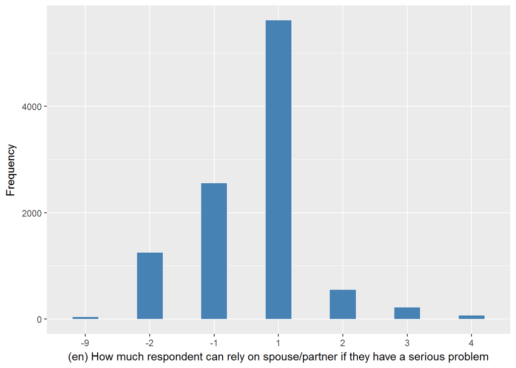

scptrc

| Sample size | Missing values |
| --- | --- |
| 10274 | 3837 |

Category

|  | 1 | 2 | 3 | 4 |
| --- | --- | --- | --- | --- |
| Frequency | 4276.00 | 1567.00 | 466.00 | 128.00 |
| Percentage | 41.62 | 15.25 | 4.54 | 1.25 |

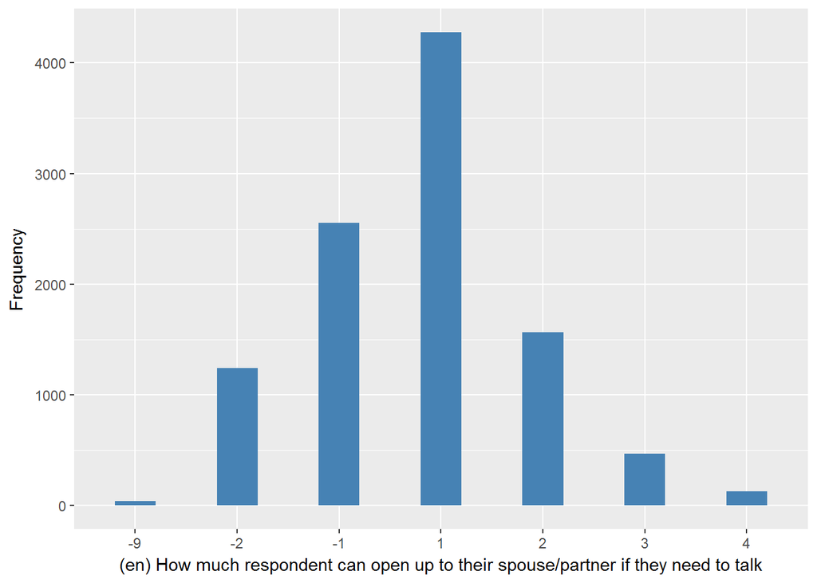

scchda

| Sample size | Missing values |
| --- | --- |
| 10274 | 2649 |

Category

|  | 1 | 2 | 3 | 4 |
| --- | --- | --- | --- | --- |
| Frequency | 2767.00 | 3540.00 | 1056.00 | 262.00 |
| Percentage | 26.93 | 34.46 | 10.28 | 2.55 |

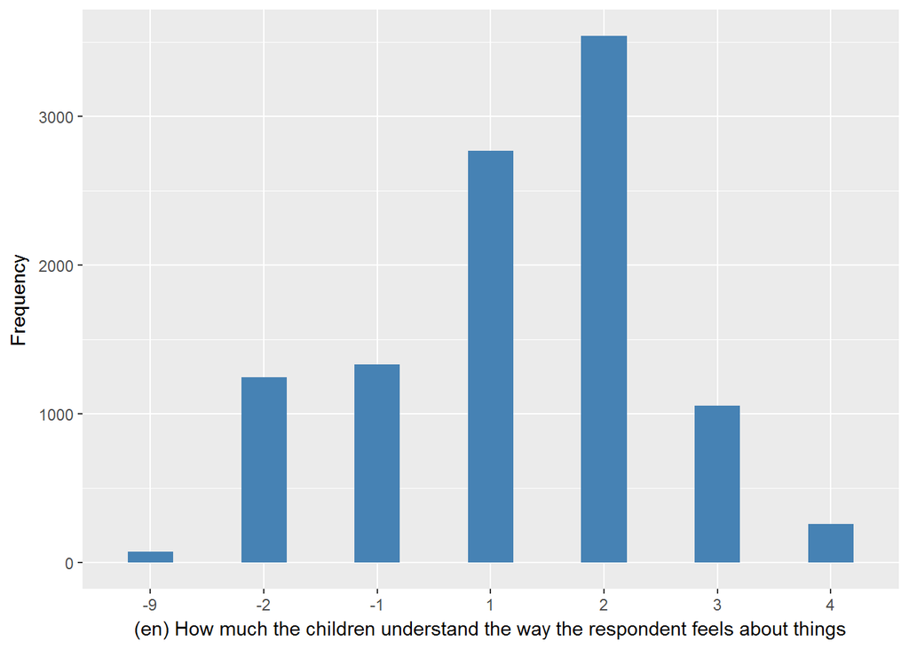

scchdb

| Sample size | Missing values |
| --- | --- |
| 10274 | 2636 |

Category

|  | 1 | 2 | 3 | 4 |
| --- | --- | --- | --- | --- |
| Frequency | 5415.00 | 1408.0 | 567.00 | 248.00 |
| Percentage | 52.71 | 13.7 | 5.52 | 2.41 |

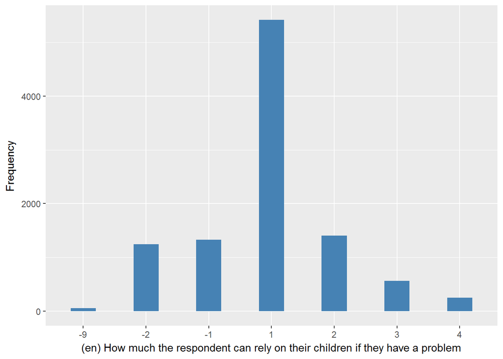

scchdc

| Sample size | Missing values |
| --- | --- |
| 10274 | 2647 |

Category

|  | 1 | 2 | 3 | 4 |
| --- | --- | --- | --- | --- |
| Frequency | 3337.00 | 2661.0 | 1220.00 | 409.00 |
| Percentage | 32.48 | 25.9 | 11.87 | 3.98 |

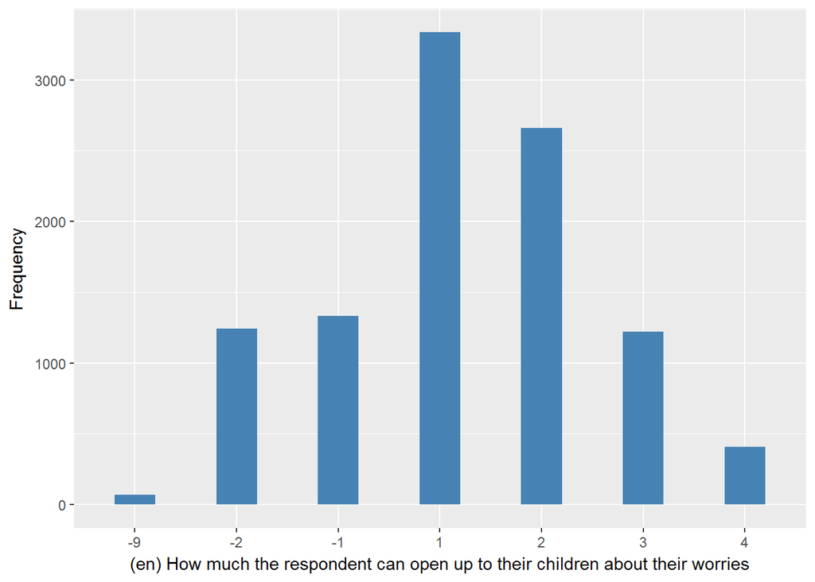

scfama

| Sample size | Missing values |
| --- | --- |
| 10274 | 2126 |

Category

|  | 1 | 2 | 3 | 4 |
| --- | --- | --- | --- | --- |
| Frequency | 1595.00 | 3336.00 | 2219.0 | 998.00 |
| Percentage | 15.52 | 32.47 | 21.6 | 9.71 |

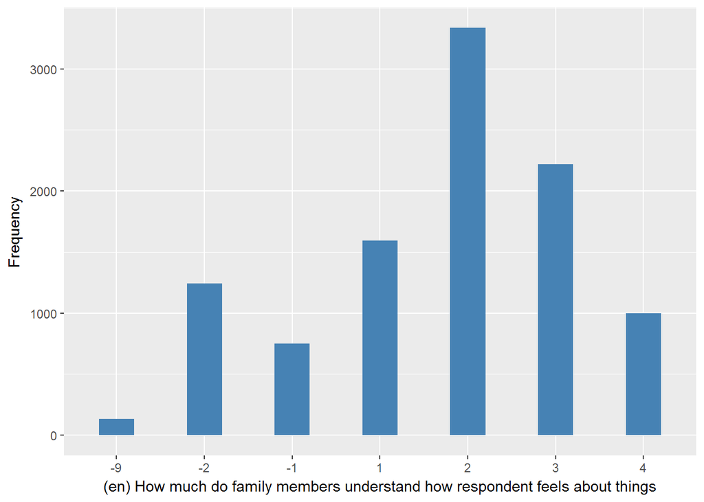

scfamb

| Sample size | Missing values |
| --- | --- |
| 10274 | 2110 |

Category

|  | 1 | 2 | 3 | 4 |
| --- | --- | --- | --- | --- |
| Frequency | 3540.00 | 2066.00 | 1504.00 | 1054.00 |
| Percentage | 34.46 | 20.11 | 14.64 | 10.26 |

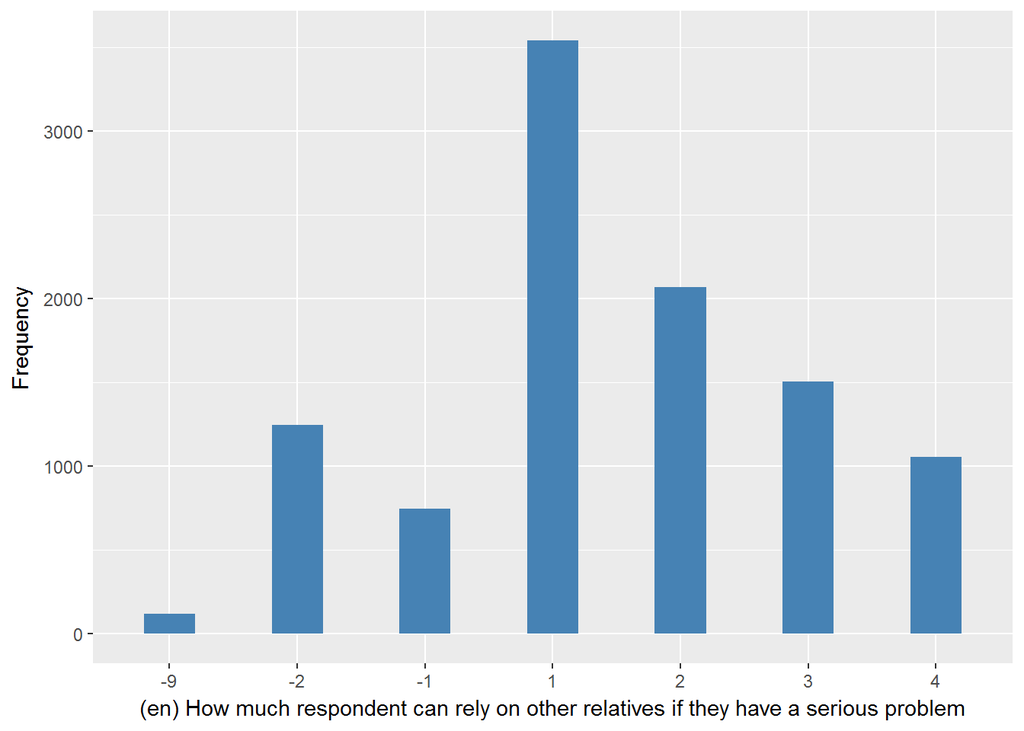

scfamc

| Sample size | Missing values |
| --- | --- |
| 10274 | 2125 |

Category

|  | 1 | 2 | 3 | 4 |
| --- | --- | --- | --- | --- |
| Frequency | 2212.00 | 2476.0 | 2093.00 | 1368.00 |
| Percentage | 21.53 | 24.1 | 20.37 | 13.32 |

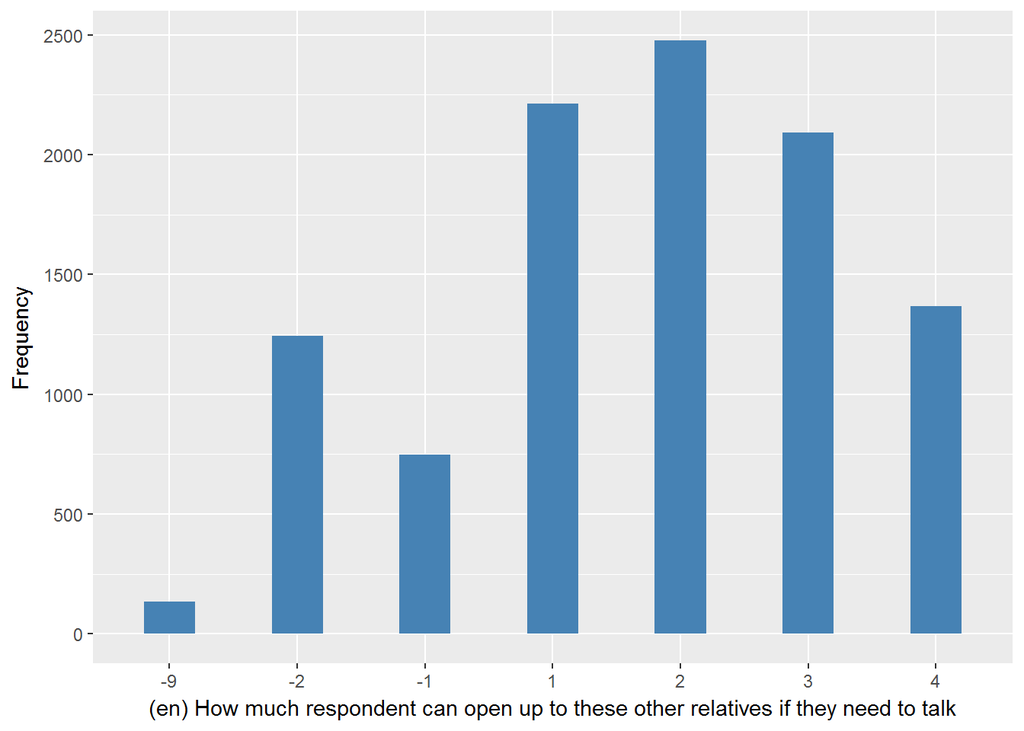

scfrda

| Sample size | Missing values |
| --- | --- |
| 10274 | 1967 |

Category

|  | 1 | 2 | 3 | 4 |
| --- | --- | --- | --- | --- |
| Frequency | 2798.00 | 3798.00 | 1535.00 | 176.00 |
| Percentage | 27.23 | 36.97 | 14.94 | 1.71 |

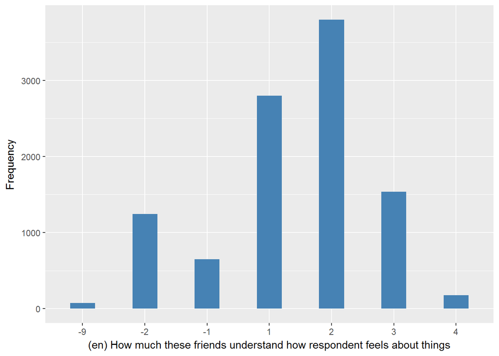

scfrdb

| Sample size | Missing values |
| --- | --- |
| 10274 | 1958 |

Category

|  | 1 | 2 | 3 | 4 |
| --- | --- | --- | --- | --- |
| Frequency | 4133.00 | 2675.00 | 1232.00 | 276.00 |
| Percentage | 40.23 | 26.04 | 11.99 | 2.69 |

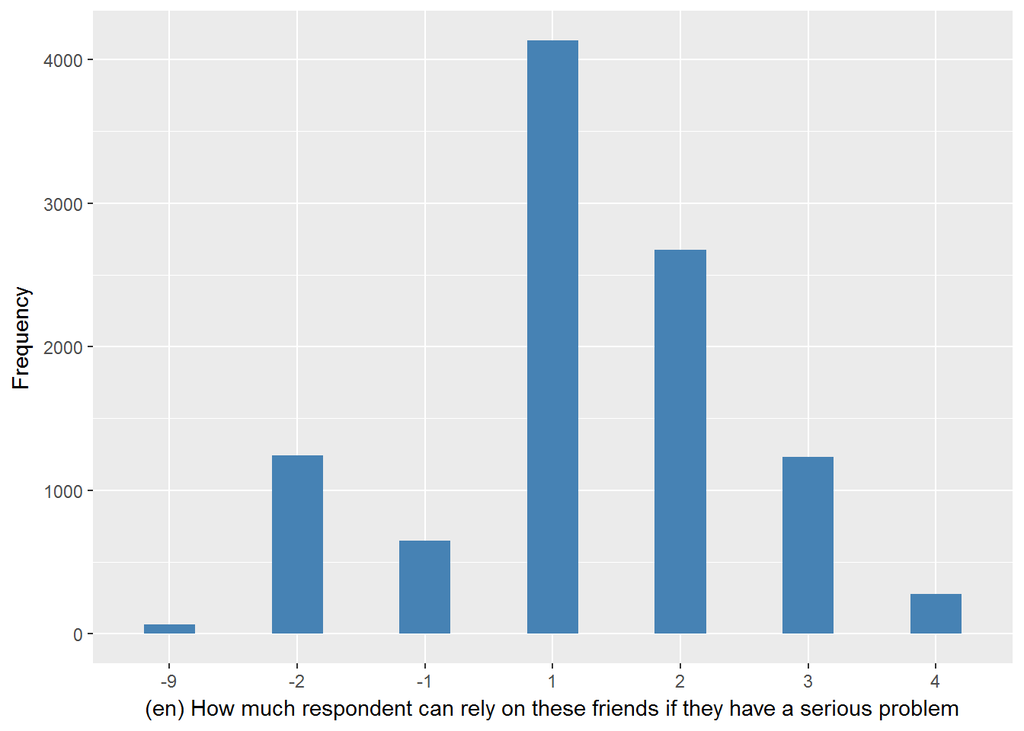

scfrdc

| Sample size | Missing values |
| --- | --- |
| 10274 | 1968 |

Category

|  | 1 | 2 | 3 | 4 |
| --- | --- | --- | --- | --- |
| Frequency | 3107.00 | 2985.00 | 1767.0 | 447.00 |
| Percentage | 30.24 | 29.05 | 17.2 | 4.35 |

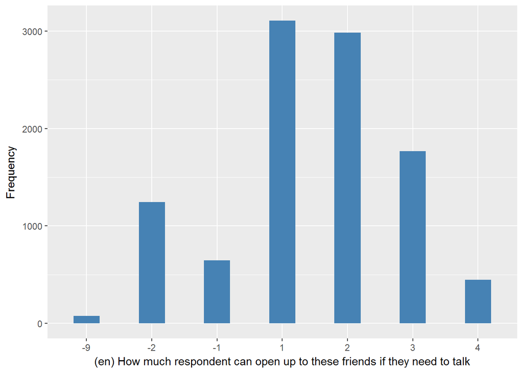

#### 2.1.5.2 Harmonisation algorithm

To compute the harmonize variable from the study-specific variable it has to be recoded as follows:

- `if any variable equals 1 or 2 then 1`
- `if all are equal 3 or 4 then 0`
- `-1 or -2 into 996`
- `-8 into 998`
- `-9 into 995`
- `NA into 999`

**R script:**

```r
ELSA_ds_w5 <- tibble(id = ELSA_w5_emot_sup$id)

ELSA_w5_emot_sup$scptra <- car::recode(as.vector(ELSA_w5_emot_sup$scptra), "NA='-999'")
ELSA_w5_emot_sup$scptrb <- car::recode(as.vector(ELSA_w5_emot_sup$scptrb), "NA='-999'")
ELSA_w5_emot_sup$scptrc <- car::recode(as.vector(ELSA_w5_emot_sup$scptrc), "NA='-999'")
ELSA_w5_emot_sup$scchda <- car::recode(as.vector(ELSA_w5_emot_sup$scchda), "NA='-999'")
ELSA_w5_emot_sup$scchdb <- car::recode(as.vector(ELSA_w5_emot_sup$scchdb), "NA='-999'")
ELSA_w5_emot_sup$scchdc <- car::recode(as.vector(ELSA_w5_emot_sup$scchdc), "NA='-999'")
ELSA_w5_emot_sup$scfama <- car::recode(as.vector(ELSA_w5_emot_sup$scfama), "NA='-999'")
ELSA_w5_emot_sup$scfamb <- car::recode(as.vector(ELSA_w5_emot_sup$scfamb), "NA='-999'")
ELSA_w5_emot_sup$scfamc <- car::recode(as.vector(ELSA_w5_emot_sup$scfamc), "NA='-999'")
ELSA_w5_emot_sup$scfrda <- car::recode(as.vector(ELSA_w5_emot_sup$scfrda), "NA='-999'")
ELSA_w5_emot_sup$scfrdb <- car::recode(as.vector(ELSA_w5_emot_sup$scfrdb), "NA='-999'")
ELSA_w5_emot_sup$scfrdc <- car::recode(as.vector(ELSA_w5_emot_sup$scfrdc), "NA='-999'")


ELSA_ds_w5$emot_sup <- c(NA)
for (i in 1:dim(ELSA_w5_emot_sup)[1]) {
    if (ELSA_w5_emot_sup$scptra[i] %in% c(1, 2) | ELSA_w5_emot_sup$scptrb[i] %in%
        c(1, 2) | ELSA_w5_emot_sup$scptrc[i] %in% c(1, 2) | ELSA_w5_emot_sup$scchda[i] %in%
        c(1, 2) | ELSA_w5_emot_sup$scchdb[i] %in% c(1, 2) | ELSA_w5_emot_sup$scchdc[i] %in%
        c(1, 2) | ELSA_w5_emot_sup$scfama[i] %in% c(1, 2) | ELSA_w5_emot_sup$scfamb[i] %in%
        c(1, 2) | ELSA_w5_emot_sup$scfamc[i] %in% c(1, 2) | ELSA_w5_emot_sup$scfrda[i] %in%
        c(1, 2) | ELSA_w5_emot_sup$scfrdb[i] %in% c(1, 2) | ELSA_w5_emot_sup$scfrdc[i] %in%
        c(1, 2)) {
        ELSA_ds_w5$emot_sup[i] = 1
    } else if (ELSA_w5_emot_sup$scptra[i] %in% c(-1, -2) & ELSA_w5_emot_sup$scptrb[i] %in%
        c(-1, -2) & ELSA_w5_emot_sup$scptrc[i] %in% c(-1, -2) & ELSA_w5_emot_sup$scchda[i] %in%
        c(-1, -2) & ELSA_w5_emot_sup$scchdb[i] %in% c(-1, -2) & ELSA_w5_emot_sup$scchdc[i] %in%
        c(-1, -2) & ELSA_w5_emot_sup$scfama[i] %in% c(-1, -2) & ELSA_w5_emot_sup$scfamb[i] %in%
        c(-1, -2) & ELSA_w5_emot_sup$scfamc[i] %in% c(-1, -2) & ELSA_w5_emot_sup$scfrda[i] %in%
        c(-1, -2) & ELSA_w5_emot_sup$scfrdb[i] %in% c(-1, -2) & ELSA_w5_emot_sup$scfrdc[i] %in%
        c(-1, -2)) {
        ELSA_ds_w5$emot_sup[i] = 996
    } else if (ELSA_w5_emot_sup$scptra[i] %in% c(3, 4, -1, -2) & ELSA_w5_emot_sup$scptrb[i] %in%
        c(3, 4, -1, -2) & ELSA_w5_emot_sup$scptrc[i] %in% c(3, 4, -1, -2) &
        ELSA_w5_emot_sup$scchda[i] %in% c(3, 4, -1, -2) & ELSA_w5_emot_sup$scchdb[i] %in%
        c(3, 4, -1, -2) & ELSA_w5_emot_sup$scchdc[i] %in% c(3, 4, -1, -2) &
        ELSA_w5_emot_sup$scfama[i] %in% c(3, 4, -1, -2) & ELSA_w5_emot_sup$scfamb[i] %in%
        c(3, 4, -1, -2) & ELSA_w5_emot_sup$scfamc[i] %in% c(3, 4, -1, -2) &
        ELSA_w5_emot_sup$scfrda[i] %in% c(3, 4, -1, -2) & ELSA_w5_emot_sup$scfrdb[i] %in%
        c(3, 4, -1, -2) & ELSA_w5_emot_sup$scfrdc[i] %in% c(3, 4, -1, -2)) {
        ELSA_ds_w5$emot_sup[i] = 0
    } else if (ELSA_w5_emot_sup$scptra[i] == -9 | ELSA_w5_emot_sup$scptrb[i] ==
        -9 | ELSA_w5_emot_sup$scptrc[i] == -9 | ELSA_w5_emot_sup$scchda[i] ==
        -9 | ELSA_w5_emot_sup$scchdb[i] == -9 | ELSA_w5_emot_sup$scchdc[i] ==
        -9 | ELSA_w5_emot_sup$scfama[i] == -9 | ELSA_w5_emot_sup$scfamb[i] ==
        -9 | ELSA_w5_emot_sup$scfamc[i] == -9 | ELSA_w5_emot_sup$scfrda[i] ==
        -9 | ELSA_w5_emot_sup$scfrdb[i] == -9 | ELSA_w5_emot_sup$scfrdc[i] ==
        -9) {
        ELSA_ds_w5$emot_sup[i] = 995
    } else if (ELSA_w5_emot_sup$scptra[i] == -8 | ELSA_w5_emot_sup$scptrb[i] ==
        -8 | ELSA_w5_emot_sup$scptrc[i] == -8 | ELSA_w5_emot_sup$scchda[i] ==
        -8 | ELSA_w5_emot_sup$scchdb[i] == -8 | ELSA_w5_emot_sup$scchdc[i] ==
        -8 | ELSA_w5_emot_sup$scfama[i] == -8 | ELSA_w5_emot_sup$scfamb[i] ==
        -8 | ELSA_w5_emot_sup$scfamc[i] == -8 | ELSA_w5_emot_sup$scfrda[i] ==
        -8 | ELSA_w5_emot_sup$scfrdb[i] == -8 | ELSA_w5_emot_sup$scfrdc[i] ==
        -8) {
        ELSA_ds_w5$emot_sup[i] = 998
    }
}

ELSA_ds_w5$emot_sup <- car::recode(as.vector(ELSA_ds_w5$emot_sup), "NA='999'")
ELSA_ds_w5$emot_sup <- labelled(ELSA_ds_w5$emot_sup, labels = c(No = 0, Yes = 1,
    Missing = 999, `Do not know` = 998, Refuse = 997, `Not applicable` = 996,
    `Don't answer` = 995, `Not attempt/not done/not yet recorded` = 994, `Disable to measure` = 993,
    Impute = 992, `CAPI/interviewer error` = 991))
```

#### 2.1.5.3 Statistics of the new harmonised variable

Receives emotional support from someone

| Sample size | Missing values |
| --- | --- |
| 10274 | 1284 |

Category

|  | 0 | 1 |
| --- | --- | --- |
| Frequency | 59.00 | 8931.00 |
| Percentage | 0.57 | 86.93 |

Type of missing

|  | 991 | 992 | 993 | 994 | 995 | 996 | 997 | 998 | 999 | NA |
| --- | --- | --- | --- | --- | --- | --- | --- | --- | --- | --- |
| Frequency | 0 | 0 | 0 | 0 | 15.00 | 1269.00 | 0 | 0 | 0 | 0 |
| Percentage | 0 | 0 | 0 | 0 | 0.15 | 12.35 | 0 | 0 | 0 | 0 |

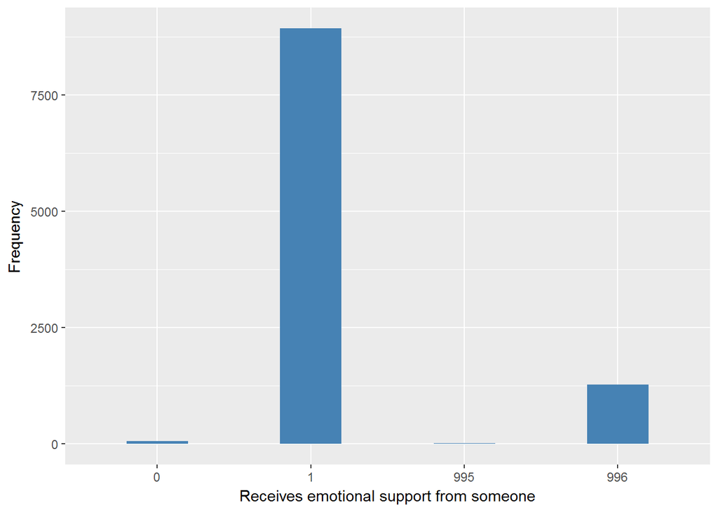

#### 2.1.5.4 Validation

### 2.1.6 Wave 6

#### 2.1.6.1 Study-specific variable description

| **Name** | `scptra` | `scptrb` | `scptrc` | `scchda` | `scchdb` | `scchdc` | `scfama` | `scfamb` | `scfamc` | `scfrda` | `scfrdb` | `scfrdc` |
| --- | --- | --- | --- | --- | --- | --- | --- | --- | --- | --- | --- | --- |
| **Label** | `how much does your spouse/partner really understand the way you feel?` | `how much can you rely on your spouse/partner if you have a serious problem?` | `how much can you open up to your spouse/partner if you need to talk about your worries?` | `how much do your children really understand the way you feel about things?` | `how much can you rely on your children if you have a serious problem?` | `how much can you open up to your children if you need to talk about your worries?` | `how much do these family members really understand the way you feel?` | `how much can you rely on these family members if you have a serious problem?` | `how much can you open up to these family members if you need to talk about your worries?` | `how much do your friends really understand the way you feel about things?` | `how much can you rely on these friends if you have a serious problem?` | `how much can you open up to these friends if you need to talk about your worries?` |
| **Table name** | `wave_6_elsa_data_v2` | `wave_6_elsa_data_v2` | `wave_6_elsa_data_v2` | `wave_6_elsa_data_v2` | `wave_6_elsa_data_v2` | `wave_6_elsa_data_v2` | `wave_6_elsa_data_v2` | `wave_6_elsa_data_v2` | `wave_6_elsa_data_v2` | `wave_6_elsa_data_v2` | `wave_6_elsa_data_v2` | `wave_6_elsa_data_v2` |
| **Categories** | `1 = A lot` `2 = Some` `3 = A little` `4 = Not at all` | `1 = A lot` `2 = Some` `3 = A little` `4 = Not at all` | `1 = A lot` `2 = Some` `3 = A little` `4 = Not at all` | `1 = A lot` `2 = Some` `3 = A little` `4 = Not at all` | `1 = A lot` `2 = Some` `3 = A little` `4 = Not at all` | `1 = A lot` `2 = Some` `3 = A little` `4 = Not at all` | `1 = A lot` `2 = Some` `3 = A little` `4 = Not at all` | `1 = A lot` `2 = Some` `3 = A little` `4 = Not at all` | `1 = A lot` `2 = Some` `3 = A little` `4 = Not at all` | `1 = A lot` `2 = Some` `3 = A little` `4 = Not at all` | `1 = A lot` `2 = Some` `3 = A little` `4 = Not at all` | `1 = A lot` `2 = Some` `3 = A little` `4 = Not at all` |
| **Missings** | `-9 = Not answered` `-1 = Item not applicable` `-8 = Don't know` `-2 = Schedule Not Applicable` | `-9 = Not answered` `-8 = Don't know` `-2 = Schedule Not Applicable` `-1 = Item not applicable` | `-9 = Not answered` `-8 = Don't know` `-2 = Schedule Not Applicable` `-1 = Item not applicable` | `-9 = Not answered` `-8 = Don't know` `-2 = Schedule Not Applicable` `-1 = Item not applicable` | `-9 = Not answered` `-8 = Don't know` `-2 = Schedule Not Applicable` `-1 = Item not applicable` | `-9 = Not answered` `-8 = Don't know` `-2 = Schedule Not Applicable` `-1 = Item not applicable` | `-9 = Not answered` `-8 = Don't know` `-2 = Schedule Not Applicable` `-1 = Item not applicable` | `-9 = Not answered` `-8 = Don't know` `-2 = Schedule Not Applicable` `-1 = Item not applicable` | `-9 = Not answered` `-8 = Don't know` `-2 = Schedule Not Applicable` `-1 = Item not applicable` | `-9 = Not answered` `-8 = Don't know` `-2 = Schedule Not Applicable` `-1 = Item not applicable` | `-9 = Not answered` `-8 = Don't know` `-2 = Schedule Not Applicable` `-1 = Item not applicable` | `-9 = Not answered` `-8 = Don't know` `-2 = Schedule Not Applicable` `-1 = Item not applicable` |
| **Description** |  |  |  |  |  |  |  |  |  |  |  |  |

scptra

| Sample size | Missing values |
| --- | --- |
| 10601 | 4101 |

Category

|  | 1 | 2 | 3 | 4 |
| --- | --- | --- | --- | --- |
| Frequency | 3572.00 | 2316.00 | 473.00 | 139.00 |
| Percentage | 33.69 | 21.85 | 4.46 | 1.31 |

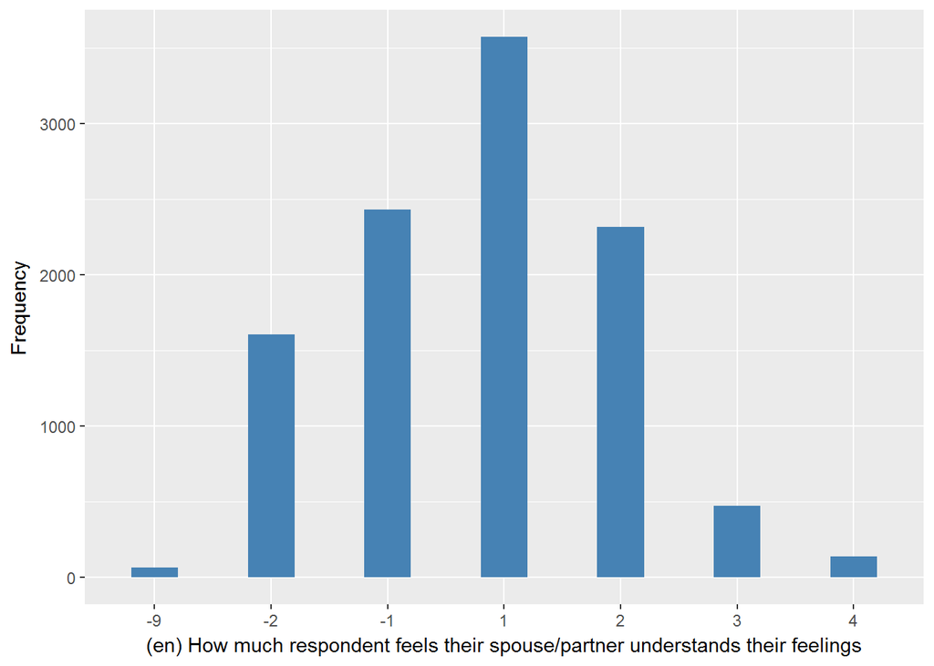

scptrb

| Sample size | Missing values |
| --- | --- |
| 10601 | 4075 |

Category

|  | 1 | 2 | 3 | 4 |
| --- | --- | --- | --- | --- |
| Frequency | 5678.00 | 548.00 | 219.00 | 81.00 |
| Percentage | 53.56 | 5.17 | 2.07 | 0.76 |

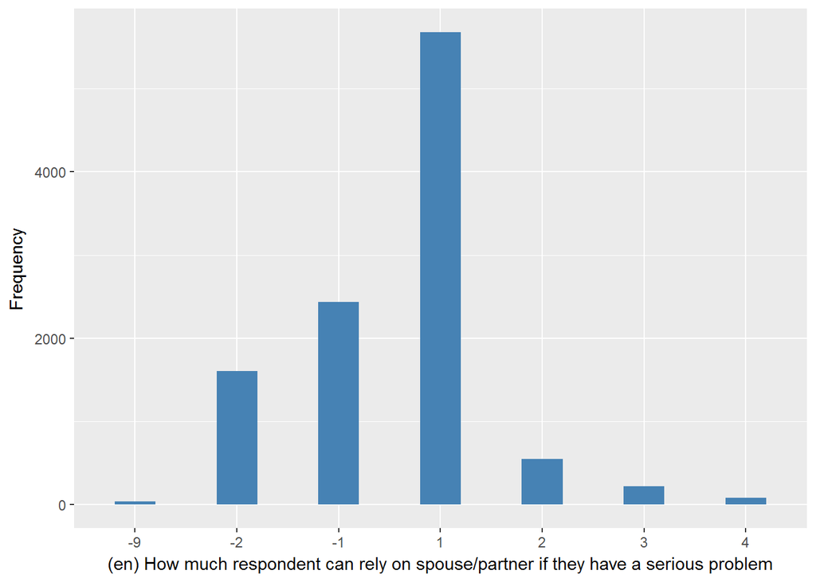

scptrc

| Sample size | Missing values |
| --- | --- |
| 10601 | 4089 |

Category

|  | 1 | 2 | 3 | 4 |
| --- | --- | --- | --- | --- |
| Frequency | 4305.00 | 1611.0 | 457.00 | 139.00 |
| Percentage | 40.61 | 15.2 | 4.31 | 1.31 |

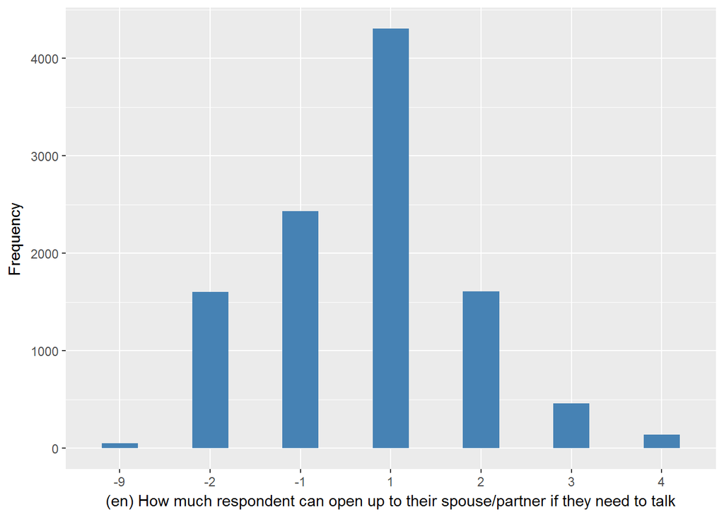

scchda

| Sample size | Missing values |
| --- | --- |
| 10601 | 2983 |

Category

|  | 1 | 2 | 3 | 4 |
| --- | --- | --- | --- | --- |
| Frequency | 2806.00 | 3422.00 | 1131.00 | 259.00 |
| Percentage | 26.47 | 32.28 | 10.67 | 2.44 |

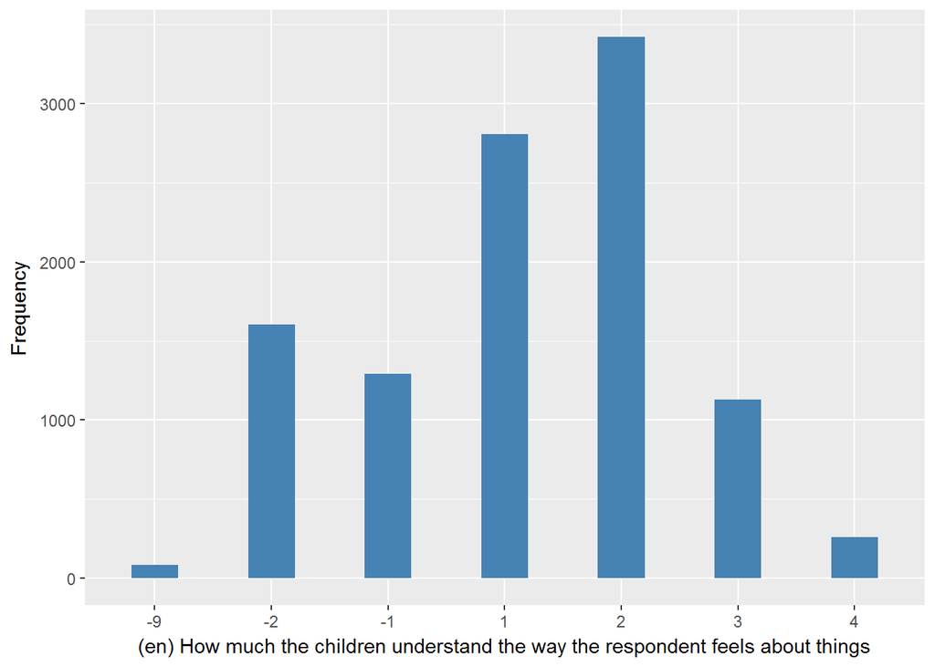

scchdb

| Sample size | Missing values |
| --- | --- |
| 10601 | 2963 |

Category

|  | 1 | 2 | 3 | 4 |
| --- | --- | --- | --- | --- |
| Frequency | 5419.00 | 1383.00 | 579.00 | 257.00 |
| Percentage | 51.12 | 13.05 | 5.46 | 2.42 |

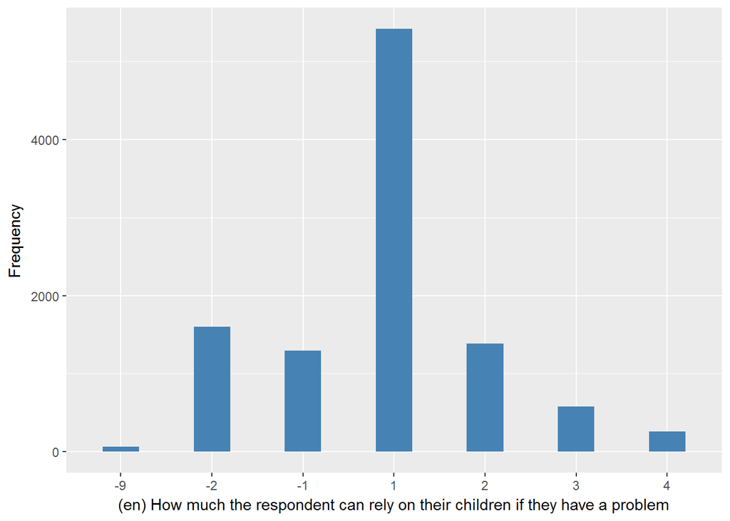

scchdc

| Sample size | Missing values |
| --- | --- |
| 10601 | 2976 |

Category

|  | 1 | 2 | 3 | 4 |
| --- | --- | --- | --- | --- |
| Frequency | 3157.00 | 2752.00 | 1251.0 | 465.00 |
| Percentage | 29.78 | 25.96 | 11.8 | 4.39 |

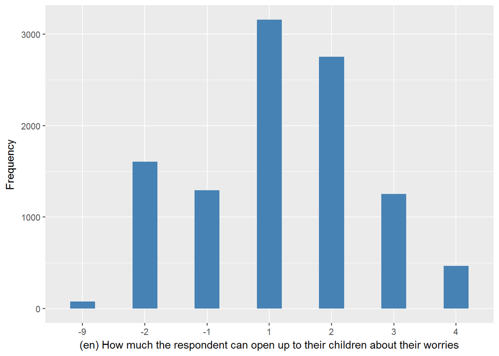

scfama

| Sample size | Missing values |
| --- | --- |
| 10601 | 2435 |

Category

|  | 1 | 2 | 3 | 4 |
| --- | --- | --- | --- | --- |
| Frequency | 1639.00 | 3261.00 | 2217.00 | 1049.0 |
| Percentage | 15.46 | 30.76 | 20.91 | 9.9 |

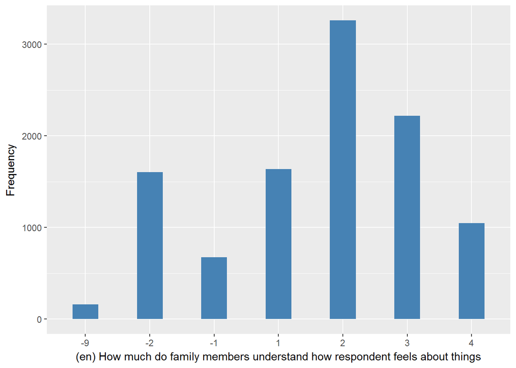

scfamb

| Sample size | Missing values |
| --- | --- |
| 10601 | 2428 |

Category

|  | 1 | 2 | 3 | 4 |
| --- | --- | --- | --- | --- |
| Frequency | 3549.00 | 2073.00 | 1471.00 | 1080.00 |
| Percentage | 33.48 | 19.55 | 13.88 | 10.19 |

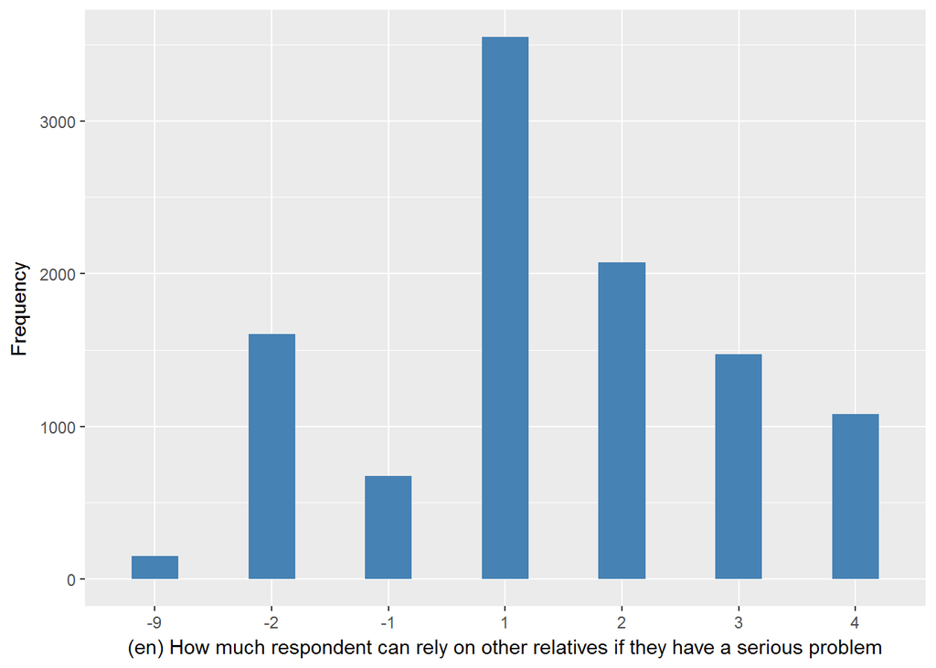

scfamc

| Sample size | Missing values |
| --- | --- |
| 10601 | 2440 |

Category

|  | 1 | 2 | 3 | 4 |
| --- | --- | --- | --- | --- |
| Frequency | 2073.00 | 2562.00 | 2071.00 | 1455.00 |
| Percentage | 19.55 | 24.17 | 19.54 | 13.73 |

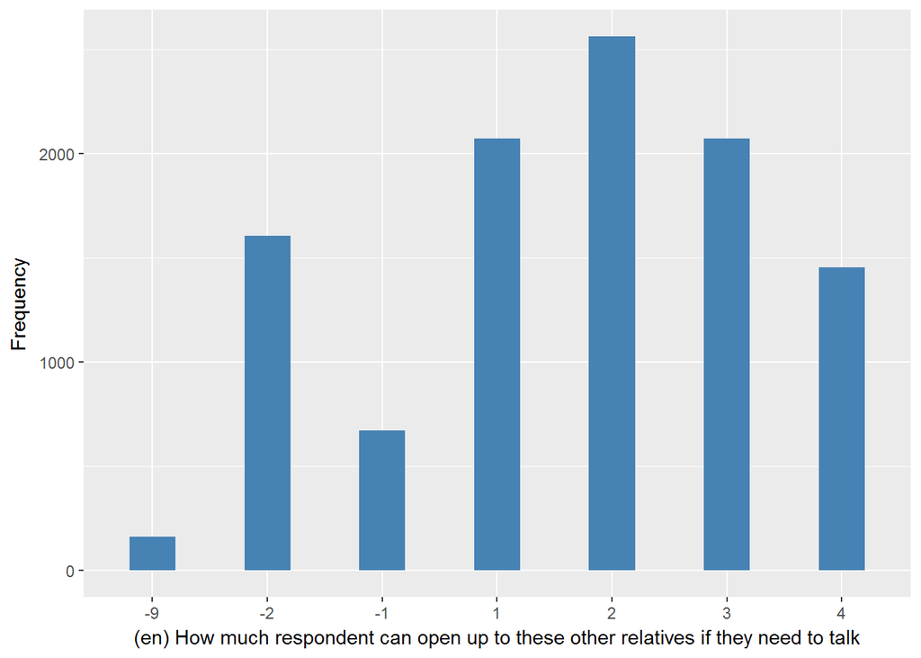

scfrda

| Sample size | Missing values |
| --- | --- |
| 10601 | 2295 |

Category

|  | 1 | 2 | 3 | 4 |
| --- | --- | --- | --- | --- |
| Frequency | 2790.00 | 3784.00 | 1530.00 | 202.00 |
| Percentage | 26.32 | 35.69 | 14.43 | 1.91 |

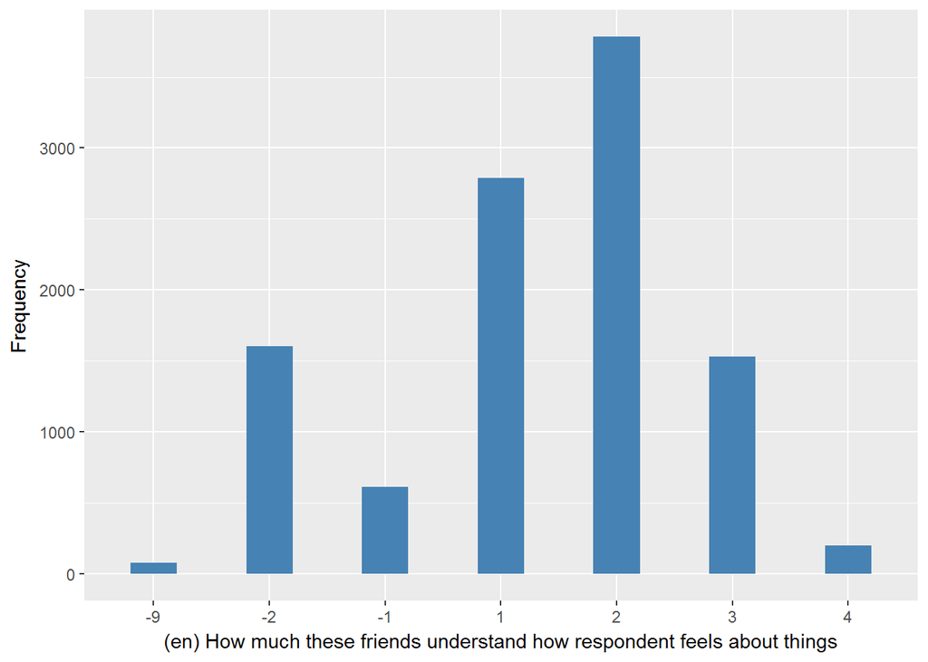

scfrdb

| Sample size | Missing values |
| --- | --- |
| 10601 | 2293 |

Category

|  | 1 | 2 | 3 | 4 |
| --- | --- | --- | --- | --- |
| Frequency | 4043.00 | 2721.00 | 1252.00 | 292.00 |
| Percentage | 38.14 | 25.67 | 11.81 | 2.75 |

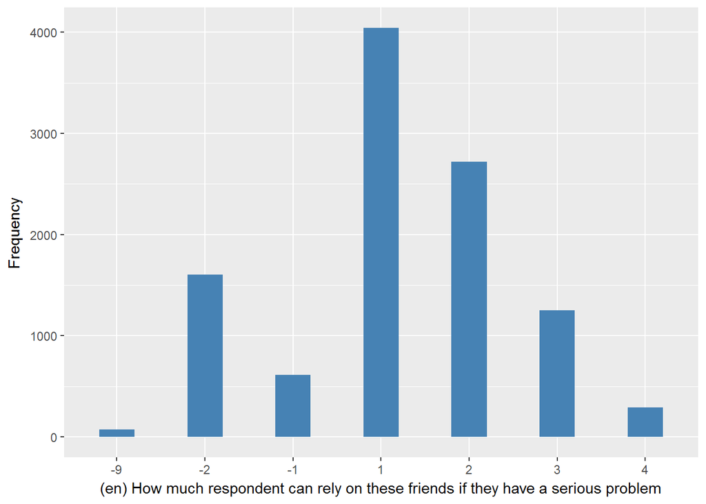

scfrdc

| Sample size | Missing values |
| --- | --- |
| 10601 | 2301 |

Category

|  | 1 | 2 | 3 | 4 |
| --- | --- | --- | --- | --- |
| Frequency | 3019.00 | 3008.00 | 1761.00 | 512.00 |
| Percentage | 28.48 | 28.37 | 16.61 | 4.83 |

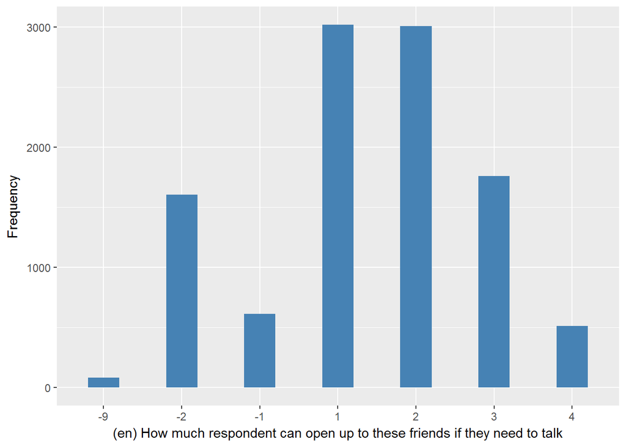

#### 2.1.6.2 Harmonisation algorithm

To compute the harmonize variable from the study-specific variable it has to be recoded as follows:

- `if any variable equals 1 or 2 then 1`
- `if all are equal 3 or 4 then 0`
- `-1 or -2 into 996`
- `-8 into 998`
- `-9 into 995`
- `NA into 999`

**R script:**

```r
ELSA_ds_w6 <- tibble(id = ELSA_w6_emot_sup$id)

ELSA_w6_emot_sup$scptra <- car::recode(as.vector(ELSA_w6_emot_sup$scptra), "NA='-999'")
ELSA_w6_emot_sup$scptrb <- car::recode(as.vector(ELSA_w6_emot_sup$scptrb), "NA='-999'")
ELSA_w6_emot_sup$scptrc <- car::recode(as.vector(ELSA_w6_emot_sup$scptrc), "NA='-999'")
ELSA_w6_emot_sup$scchda <- car::recode(as.vector(ELSA_w6_emot_sup$scchda), "NA='-999'")
ELSA_w6_emot_sup$scchdb <- car::recode(as.vector(ELSA_w6_emot_sup$scchdb), "NA='-999'")
ELSA_w6_emot_sup$scchdc <- car::recode(as.vector(ELSA_w6_emot_sup$scchdc), "NA='-999'")
ELSA_w6_emot_sup$scfama <- car::recode(as.vector(ELSA_w6_emot_sup$scfama), "NA='-999'")
ELSA_w6_emot_sup$scfamb <- car::recode(as.vector(ELSA_w6_emot_sup$scfamb), "NA='-999'")
ELSA_w6_emot_sup$scfamc <- car::recode(as.vector(ELSA_w6_emot_sup$scfamc), "NA='-999'")
ELSA_w6_emot_sup$scfrda <- car::recode(as.vector(ELSA_w6_emot_sup$scfrda), "NA='-999'")
ELSA_w6_emot_sup$scfrdb <- car::recode(as.vector(ELSA_w6_emot_sup$scfrdb), "NA='-999'")
ELSA_w6_emot_sup$scfrdc <- car::recode(as.vector(ELSA_w6_emot_sup$scfrdc), "NA='-999'")


ELSA_ds_w6$emot_sup <- c(NA)
for (i in 1:dim(ELSA_w6_emot_sup)[1]) {
    if (ELSA_w6_emot_sup$scptra[i] %in% c(1, 2) | ELSA_w6_emot_sup$scptrb[i] %in%
        c(1, 2) | ELSA_w6_emot_sup$scptrc[i] %in% c(1, 2) | ELSA_w6_emot_sup$scchda[i] %in%
        c(1, 2) | ELSA_w6_emot_sup$scchdb[i] %in% c(1, 2) | ELSA_w6_emot_sup$scchdc[i] %in%
        c(1, 2) | ELSA_w6_emot_sup$scfama[i] %in% c(1, 2) | ELSA_w6_emot_sup$scfamb[i] %in%
        c(1, 2) | ELSA_w6_emot_sup$scfamc[i] %in% c(1, 2) | ELSA_w6_emot_sup$scfrda[i] %in%
        c(1, 2) | ELSA_w6_emot_sup$scfrdb[i] %in% c(1, 2) | ELSA_w6_emot_sup$scfrdc[i] %in%
        c(1, 2)) {
        ELSA_ds_w6$emot_sup[i] = 1
    } else if (ELSA_w6_emot_sup$scptra[i] %in% c(-1, -2) & ELSA_w6_emot_sup$scptrb[i] %in%
        c(-1, -2) & ELSA_w6_emot_sup$scptrc[i] %in% c(-1, -2) & ELSA_w6_emot_sup$scchda[i] %in%
        c(-1, -2) & ELSA_w6_emot_sup$scchdb[i] %in% c(-1, -2) & ELSA_w6_emot_sup$scchdc[i] %in%
        c(-1, -2) & ELSA_w6_emot_sup$scfama[i] %in% c(-1, -2) & ELSA_w6_emot_sup$scfamb[i] %in%
        c(-1, -2) & ELSA_w6_emot_sup$scfamc[i] %in% c(-1, -2) & ELSA_w6_emot_sup$scfrda[i] %in%
        c(-1, -2) & ELSA_w6_emot_sup$scfrdb[i] %in% c(-1, -2) & ELSA_w6_emot_sup$scfrdc[i] %in%
        c(-1, -2)) {
        ELSA_ds_w6$emot_sup[i] = 996
    } else if (ELSA_w6_emot_sup$scptra[i] %in% c(3, 4, -1, -2) & ELSA_w6_emot_sup$scptrb[i] %in%
        c(3, 4, -1, -2) & ELSA_w6_emot_sup$scptrc[i] %in% c(3, 4, -1, -2) &
        ELSA_w6_emot_sup$scchda[i] %in% c(3, 4, -1, -2) & ELSA_w6_emot_sup$scchdb[i] %in%
        c(3, 4, -1, -2) & ELSA_w6_emot_sup$scchdc[i] %in% c(3, 4, -1, -2) &
        ELSA_w6_emot_sup$scfama[i] %in% c(3, 4, -1, -2) & ELSA_w6_emot_sup$scfamb[i] %in%
        c(3, 4, -1, -2) & ELSA_w6_emot_sup$scfamc[i] %in% c(3, 4, -1, -2) &
        ELSA_w6_emot_sup$scfrda[i] %in% c(3, 4, -1, -2) & ELSA_w6_emot_sup$scfrdb[i] %in%
        c(3, 4, -1, -2) & ELSA_w6_emot_sup$scfrdc[i] %in% c(3, 4, -1, -2)) {
        ELSA_ds_w6$emot_sup[i] = 0
    } else if (ELSA_w6_emot_sup$scptra[i] == -9 | ELSA_w6_emot_sup$scptrb[i] ==
        -9 | ELSA_w6_emot_sup$scptrc[i] == -9 | ELSA_w6_emot_sup$scchda[i] ==
        -9 | ELSA_w6_emot_sup$scchdb[i] == -9 | ELSA_w6_emot_sup$scchdc[i] ==
        -9 | ELSA_w6_emot_sup$scfama[i] == -9 | ELSA_w6_emot_sup$scfamb[i] ==
        -9 | ELSA_w6_emot_sup$scfamc[i] == -9 | ELSA_w6_emot_sup$scfrda[i] ==
        -9 | ELSA_w6_emot_sup$scfrdb[i] == -9 | ELSA_w6_emot_sup$scfrdc[i] ==
        -9) {
        ELSA_ds_w6$emot_sup[i] = 995
    } else if (ELSA_w6_emot_sup$scptra[i] == -8 | ELSA_w6_emot_sup$scptrb[i] ==
        -8 | ELSA_w6_emot_sup$scptrc[i] == -8 | ELSA_w6_emot_sup$scchda[i] ==
        -8 | ELSA_w6_emot_sup$scchdb[i] == -8 | ELSA_w6_emot_sup$scchdc[i] ==
        -8 | ELSA_w6_emot_sup$scfama[i] == -8 | ELSA_w6_emot_sup$scfamb[i] ==
        -8 | ELSA_w6_emot_sup$scfamc[i] == -8 | ELSA_w6_emot_sup$scfrda[i] ==
        -8 | ELSA_w6_emot_sup$scfrdb[i] == -8 | ELSA_w6_emot_sup$scfrdc[i] ==
        -8) {
        ELSA_ds_w6$emot_sup[i] = 998
    }
}

ELSA_ds_w6$emot_sup <- car::recode(as.vector(ELSA_ds_w6$emot_sup), "NA='999'")
ELSA_ds_w6$emot_sup <- labelled(ELSA_ds_w6$emot_sup, labels = c(No = 0, Yes = 1,
    Missing = 999, `Do not know` = 998, Refuse = 997, `Not applicable` = 996,
    `Don't answer` = 995, `Not attempt/not done/not yet recorded` = 994, `Disable to measure` = 993,
    Impute = 992, `CAPI/interviewer error` = 991))
```

#### 2.1.6.3 Statistics of the new harmonised variable

Receives emotional support from someone

| Sample size | Missing values |
| --- | --- |
| 10601 | 1637 |

Category

|  | 0 | 1 |
| --- | --- | --- |
| Frequency | 50.00 | 8914.00 |
| Percentage | 0.47 | 84.09 |

Type of missing

|  | 991 | 992 | 993 | 994 | 995 | 996 | 997 | 998 | 999 | NA |
| --- | --- | --- | --- | --- | --- | --- | --- | --- | --- | --- |
| Frequency | 0 | 0 | 0 | 0 | 15.00 | 1622.0 | 0 | 0 | 0 | 0 |
| Percentage | 0 | 0 | 0 | 0 | 0.14 | 15.3 | 0 | 0 | 0 | 0 |

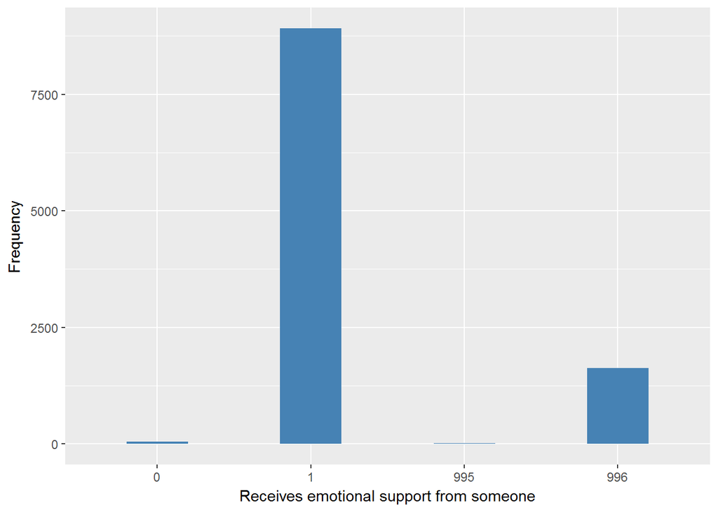

#### 2.1.6.4 Validation

### 2.1.7 Wave 7

#### 2.1.7.1 Study-specific variable description

| **Name** | `scptra` | `scptrb` | `scptrc` | `scchda` | `scchdb` | `scchdc` | `scfama` | `scfamb` | `scfamc` | `scfrda` | `scfrdb` | `scfrdc` |
| --- | --- | --- | --- | --- | --- | --- | --- | --- | --- | --- | --- | --- |
| **Label** | `how much does your spouse/partner really understand the way you feel?` | `how much can you rely on your spouse/partner if you have a serious problem?` | `how much can you open up to your spouse/partner if you need to talk about your worries?` | `how much do your children really understand the way you feel about things?` | `how much can you rely on your children if you have a serious problem?` | `how much can you open up to your children if you need to talk about your worries?` | `how much do these family members really understand the way you feel?` | `how much can you rely on these family members if you have a serious problem?` | `how much can you open up to these family members if you need to talk about your worries?` | `how much do your friends really understand the way you feel about things?` | `how much can you rely on these friends if you have a serious problem?` | `how much can you open up to these friends if you need to talk about your worries?` |
| **Table name** | `wave_7_elsa_data` | `wave_7_elsa_data` | `wave_7_elsa_data` | `wave_7_elsa_data` | `wave_7_elsa_data` | `wave_7_elsa_data` | `wave_7_elsa_data` | `wave_7_elsa_data` | `wave_7_elsa_data` | `wave_7_elsa_data` | `wave_7_elsa_data` | `wave_7_elsa_data` |
| **Categories** | `1 = A lot` `2 = Some` `3 = A little` `4 = Not at all` | `1 = A lot` `2 = Some` `3 = A little` `4 = Not at all` | `1 = A lot` `2 = Some` `3 = A little` `4 = Not at all` | `1 = A lot` `2 = Some` `3 = A little` `4 = Not at all` | `1 = A lot` `2 = Some` `3 = A little` `4 = Not at all` | `1 = A lot` `2 = Some` `3 = A little` `4 = Not at all` | `1 = A lot` `2 = Some` `3 = A little` `4 = Not at all` | `1 = A lot` `2 = Some` `3 = A little` `4 = Not at all` | `1 = A lot` `2 = Some` `3 = A little` `4 = Not at all` | `1 = A lot` `2 = Some` `3 = A little` `4 = Not at all` | `1 = A lot` `2 = Some` `3 = A little` `4 = Not at all` | `1 = A lot` `2 = Some` `3 = A little` `4 = Not at all` |
| **Missings** | `-9 = Not answered` `-1 = Item not applicable` `-8 = Don't know` `-2 = Schedule Not Applicable` | `-9 = Not answered` `-8 = Don't know` `-2 = Schedule Not Applicable` `-1 = Item not applicable` | `-9 = Not answered` `-8 = Don't know` `-2 = Schedule Not Applicable` `-1 = Item not applicable` | `-9 = Not answered` `-8 = Don't know` `-2 = Schedule Not Applicable` `-1 = Item not applicable` | `-9 = Not answered` `-8 = Don't know` `-2 = Schedule Not Applicable` `-1 = Item not applicable` | `-9 = Not answered` `-8 = Don't know` `-2 = Schedule Not Applicable` `-1 = Item not applicable` | `-9 = Not answered` `-8 = Don't know` `-2 = Schedule Not Applicable` `-1 = Item not applicable` | `-9 = Not answered` `-8 = Don't know` `-2 = Schedule Not Applicable` `-1 = Item not applicable` | `-9 = Not answered` `-8 = Don't know` `-2 = Schedule Not Applicable` `-1 = Item not applicable` | `-9 = Not answered` `-8 = Don't know` `-2 = Schedule Not Applicable` `-1 = Item not applicable` | `-9 = Not answered` `-8 = Don't know` `-2 = Schedule Not Applicable` `-1 = Item not applicable` | `-9 = Not answered` `-8 = Don't know` `-2 = Schedule Not Applicable` `-1 = Item not applicable` |
| **Description** |  |  |  |  |  |  |  |  |  |  |  |  |

scptra

| Sample size | Missing values |
| --- | --- |
| 9666 | 3765 |

Category

|  | 1 | 2 | 3 | 4 |
| --- | --- | --- | --- | --- |
| Frequency | 3570.00 | 1898.00 | 344.00 | 89.00 |
| Percentage | 36.93 | 19.64 | 3.56 | 0.92 |

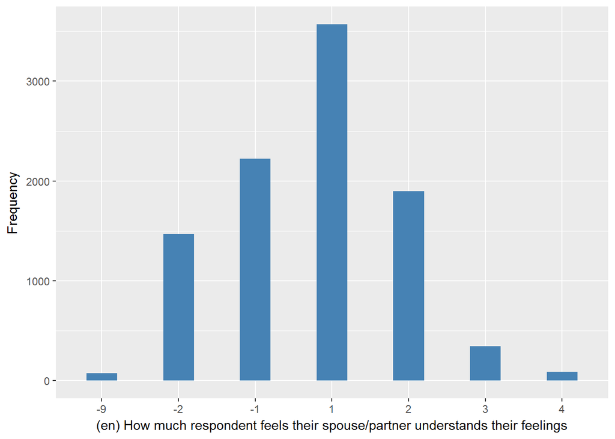

scptrb

| Sample size | Missing values |
| --- | --- |
| 9666 | 3751 |

Category

|  | 1 | 2 | 3 | 4 |
| --- | --- | --- | --- | --- |
| Frequency | 5297.0 | 425.0 | 138.00 | 55.00 |
| Percentage | 54.8 | 4.4 | 1.43 | 0.57 |

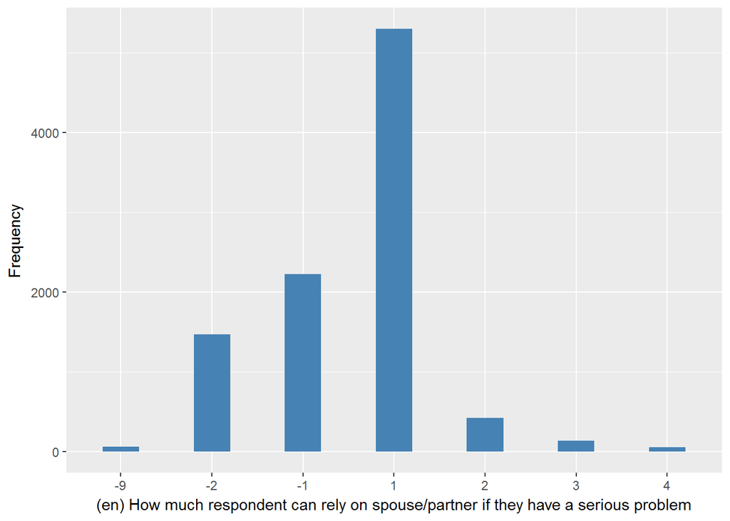

scptrc

| Sample size | Missing values |
| --- | --- |
| 9666 | 3759 |

Category

|  | 1 | 2 | 3 | 4 |
| --- | --- | --- | --- | --- |
| Frequency | 4077.00 | 1388.00 | 331.00 | 111.00 |
| Percentage | 42.18 | 14.36 | 3.42 | 1.15 |

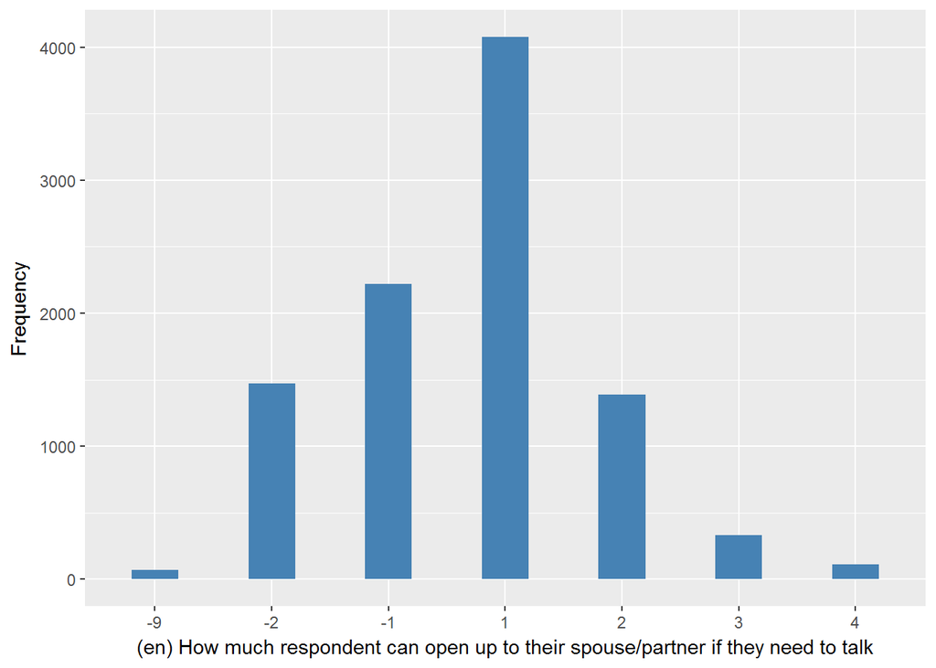

scchda

| Sample size | Missing values |
| --- | --- |
| 9666 | 2760 |

Category

|  | 1 | 2 | 3 | 4 |
| --- | --- | --- | --- | --- |
| Frequency | 2841.00 | 3082.00 | 772.00 | 211.00 |
| Percentage | 29.39 | 31.88 | 7.99 | 2.18 |

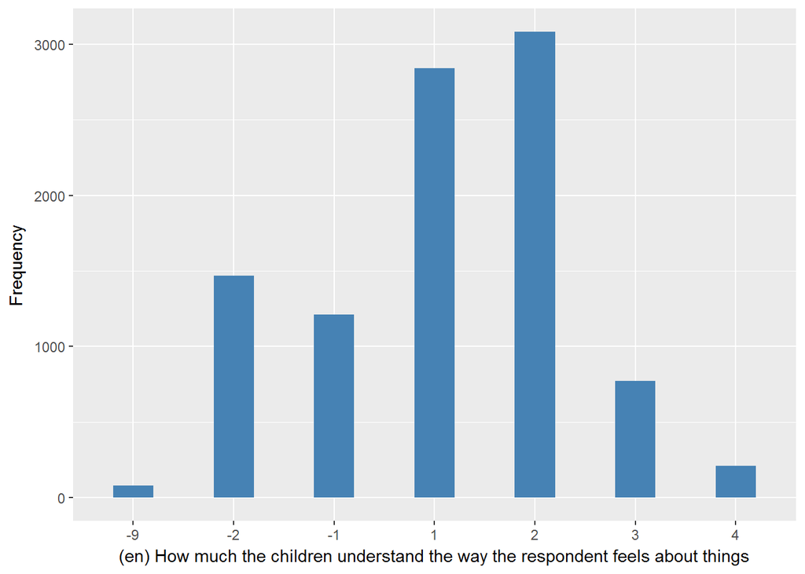

scchdb

| Sample size | Missing values |
| --- | --- |
| 9666 | 2742 |

Category

|  | 1 | 2 | 3 | 4 |
| --- | --- | --- | --- | --- |
| Frequency | 5215.00 | 1112.0 | 425.0 | 172.00 |
| Percentage | 53.95 | 11.5 | 4.4 | 1.78 |

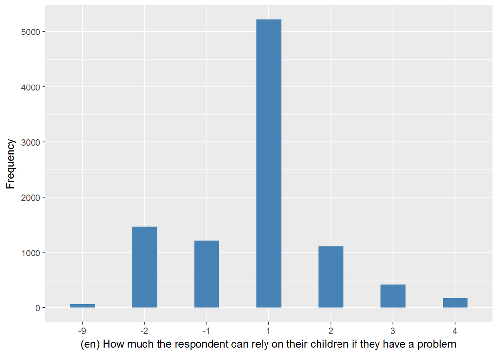

scchdc

| Sample size | Missing values |
| --- | --- |
| 9666 | 2755 |

Category

|  | 1 | 2 | 3 | 4 |
| --- | --- | --- | --- | --- |
| Frequency | 3153.00 | 2417.00 | 1017.00 | 324.00 |
| Percentage | 32.62 | 25.01 | 10.52 | 3.35 |

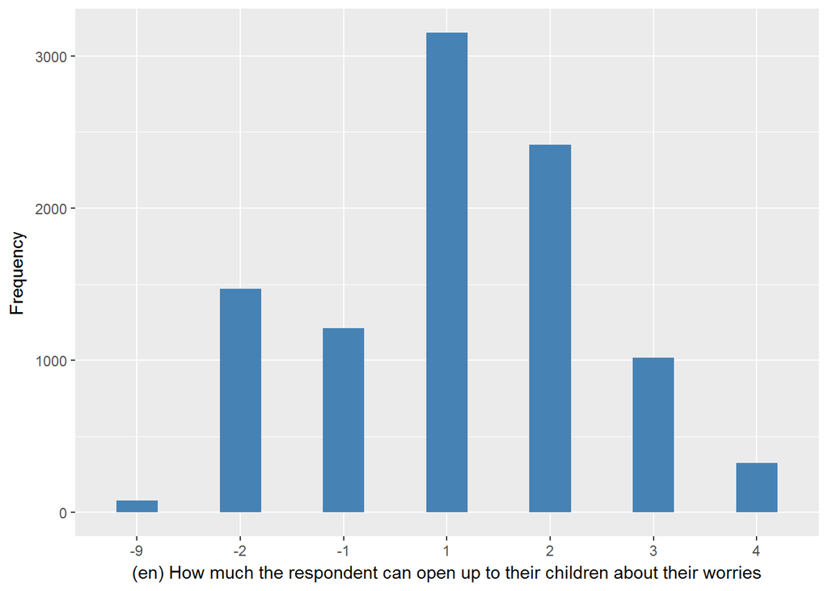

scfama

| Sample size | Missing values |
| --- | --- |
| 9666 | 2235 |

Category

|  | 1 | 2 | 3 | 4 |
| --- | --- | --- | --- | --- |
| Frequency | 1581.00 | 3076.00 | 1863.00 | 911.00 |
| Percentage | 16.36 | 31.82 | 19.27 | 9.42 |

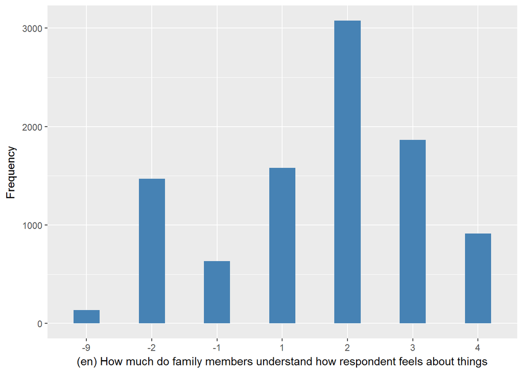

scfamb

| Sample size | Missing values |
| --- | --- |
| 9666 | 2223 |

Category

|  | 1 | 2 | 3 | 4 |
| --- | --- | --- | --- | --- |
| Frequency | 3492.00 | 1821.00 | 1225.00 | 905.00 |
| Percentage | 36.13 | 18.84 | 12.67 | 9.36 |

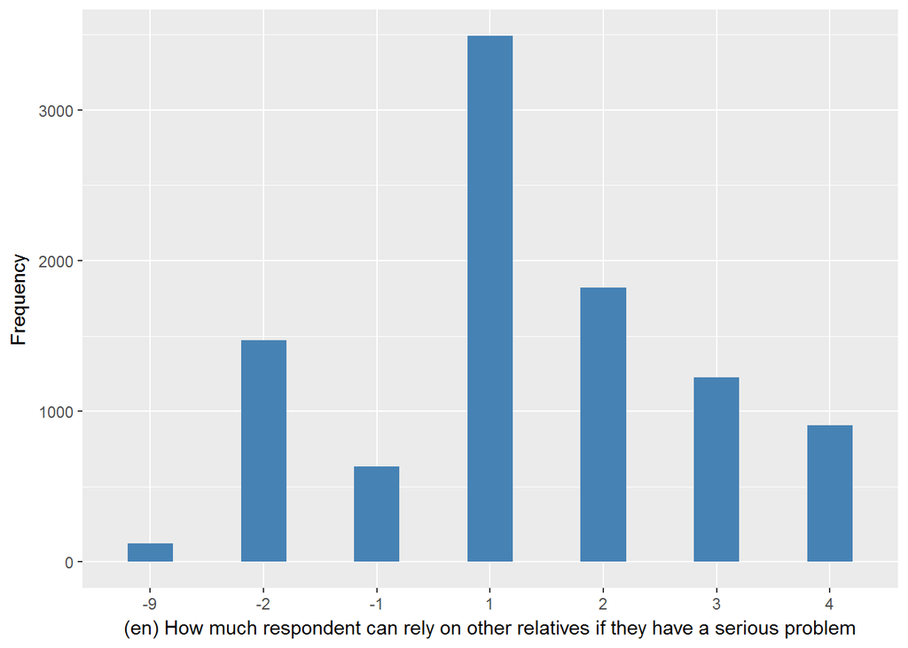

scfamc

| Sample size | Missing values |
| --- | --- |
| 9666 | 2233 |

Category

|  | 1 | 2 | 3 | 4 |
| --- | --- | --- | --- | --- |
| Frequency | 2073.00 | 2375.00 | 1746.00 | 1239.00 |
| Percentage | 21.45 | 24.57 | 18.06 | 12.82 |

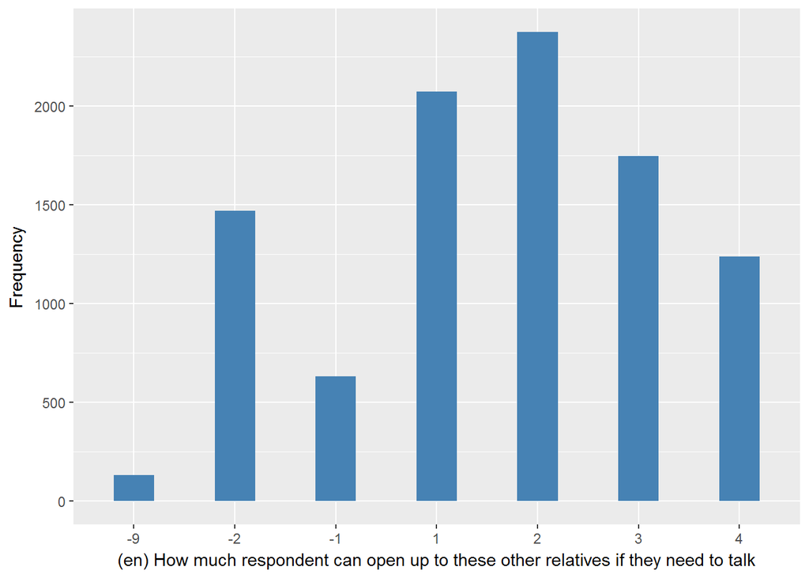

scfrda

| Sample size | Missing values |
| --- | --- |
| 9666 | 2118 |

Category

|  | 1 | 2 | 3 | 4 |
| --- | --- | --- | --- | --- |
| Frequency | 2767.00 | 3410.00 | 1229.00 | 142.00 |
| Percentage | 28.63 | 35.28 | 12.71 | 1.47 |

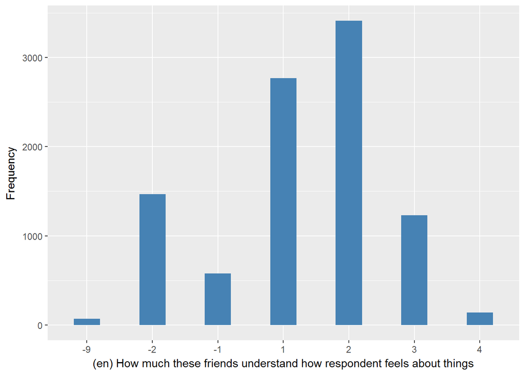

scfrdb

| Sample size | Missing values |
| --- | --- |
| 9666 | 2119 |

Category

|  | 1 | 2 | 3 | 4 |
| --- | --- | --- | --- | --- |
| Frequency | 3940.00 | 2470.00 | 946.00 | 191.00 |
| Percentage | 40.76 | 25.55 | 9.79 | 1.98 |

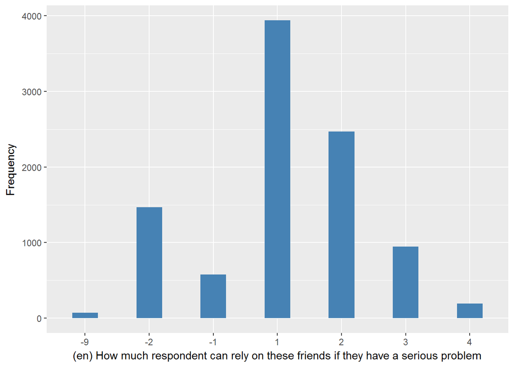

scfrdc

| Sample size | Missing values |
| --- | --- |
| 9666 | 2127 |

Category

|  | 1 | 2 | 3 | 4 |
| --- | --- | --- | --- | --- |
| Frequency | 2887.00 | 2839.00 | 1450 | 363.00 |
| Percentage | 29.87 | 29.37 | 15 | 3.76 |

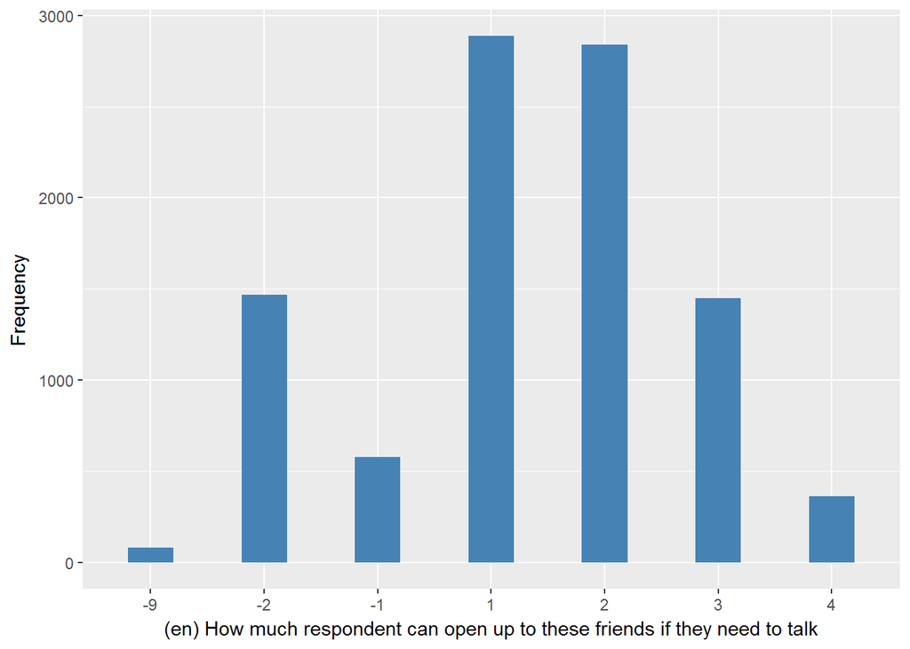

#### 2.1.7.2 Harmonisation algorithm

To compute the harmonize variable from the study-specific variable it has to be recoded as follows:

- `if any variable equals 1 or 2 then 1`
- `if all are equal 3 or 4 then 0`
- `-1 or -2 into 996`
- `-8 into 998`
- `-9 into 995`
- `NA into 999`

**R script:**

```r
ELSA_ds_w7 <- tibble(id = ELSA_w7_emot_sup$id)

ELSA_w7_emot_sup$scptra <- car::recode(as.vector(ELSA_w7_emot_sup$scptra), "NA='-999'")
ELSA_w7_emot_sup$scptrb <- car::recode(as.vector(ELSA_w7_emot_sup$scptrb), "NA='-999'")
ELSA_w7_emot_sup$scptrc <- car::recode(as.vector(ELSA_w7_emot_sup$scptrc), "NA='-999'")
ELSA_w7_emot_sup$scchda <- car::recode(as.vector(ELSA_w7_emot_sup$scchda), "NA='-999'")
ELSA_w7_emot_sup$scchdb <- car::recode(as.vector(ELSA_w7_emot_sup$scchdb), "NA='-999'")
ELSA_w7_emot_sup$scchdc <- car::recode(as.vector(ELSA_w7_emot_sup$scchdc), "NA='-999'")
ELSA_w7_emot_sup$scfama <- car::recode(as.vector(ELSA_w7_emot_sup$scfama), "NA='-999'")
ELSA_w7_emot_sup$scfamb <- car::recode(as.vector(ELSA_w7_emot_sup$scfamb), "NA='-999'")
ELSA_w7_emot_sup$scfamc <- car::recode(as.vector(ELSA_w7_emot_sup$scfamc), "NA='-999'")
ELSA_w7_emot_sup$scfrda <- car::recode(as.vector(ELSA_w7_emot_sup$scfrda), "NA='-999'")
ELSA_w7_emot_sup$scfrdb <- car::recode(as.vector(ELSA_w7_emot_sup$scfrdb), "NA='-999'")
ELSA_w7_emot_sup$scfrdc <- car::recode(as.vector(ELSA_w7_emot_sup$scfrdc), "NA='-999'")


ELSA_ds_w7$emot_sup <- c(NA)
for (i in 1:dim(ELSA_w7_emot_sup)[1]) {
    if (ELSA_w7_emot_sup$scptra[i] %in% c(1, 2) | ELSA_w7_emot_sup$scptrb[i] %in%
        c(1, 2) | ELSA_w7_emot_sup$scptrc[i] %in% c(1, 2) | ELSA_w7_emot_sup$scchda[i] %in%
        c(1, 2) | ELSA_w7_emot_sup$scchdb[i] %in% c(1, 2) | ELSA_w7_emot_sup$scchdc[i] %in%
        c(1, 2) | ELSA_w7_emot_sup$scfama[i] %in% c(1, 2) | ELSA_w7_emot_sup$scfamb[i] %in%
        c(1, 2) | ELSA_w7_emot_sup$scfamc[i] %in% c(1, 2) | ELSA_w7_emot_sup$scfrda[i] %in%
        c(1, 2) | ELSA_w7_emot_sup$scfrdb[i] %in% c(1, 2) | ELSA_w7_emot_sup$scfrdc[i] %in%
        c(1, 2)) {
        ELSA_ds_w7$emot_sup[i] = 1
    } else if (ELSA_w7_emot_sup$scptra[i] %in% c(-1, -2) & ELSA_w7_emot_sup$scptrb[i] %in%
        c(-1, -2) & ELSA_w7_emot_sup$scptrc[i] %in% c(-1, -2) & ELSA_w7_emot_sup$scchda[i] %in%
        c(-1, -2) & ELSA_w7_emot_sup$scchdb[i] %in% c(-1, -2) & ELSA_w7_emot_sup$scchdc[i] %in%
        c(-1, -2) & ELSA_w7_emot_sup$scfama[i] %in% c(-1, -2) & ELSA_w7_emot_sup$scfamb[i] %in%
        c(-1, -2) & ELSA_w7_emot_sup$scfamc[i] %in% c(-1, -2) & ELSA_w7_emot_sup$scfrda[i] %in%
        c(-1, -2) & ELSA_w7_emot_sup$scfrdb[i] %in% c(-1, -2) & ELSA_w7_emot_sup$scfrdc[i] %in%
        c(-1, -2)) {
        ELSA_ds_w7$emot_sup[i] = 996
    } else if (ELSA_w7_emot_sup$scptra[i] %in% c(3, 4, -1, -2) & ELSA_w7_emot_sup$scptrb[i] %in%
        c(3, 4, -1, -2) & ELSA_w7_emot_sup$scptrc[i] %in% c(3, 4, -1, -2) &
        ELSA_w7_emot_sup$scchda[i] %in% c(3, 4, -1, -2) & ELSA_w7_emot_sup$scchdb[i] %in%
        c(3, 4, -1, -2) & ELSA_w7_emot_sup$scchdc[i] %in% c(3, 4, -1, -2) &
        ELSA_w7_emot_sup$scfama[i] %in% c(3, 4, -1, -2) & ELSA_w7_emot_sup$scfamb[i] %in%
        c(3, 4, -1, -2) & ELSA_w7_emot_sup$scfamc[i] %in% c(3, 4, -1, -2) &
        ELSA_w7_emot_sup$scfrda[i] %in% c(3, 4, -1, -2) & ELSA_w7_emot_sup$scfrdb[i] %in%
        c(3, 4, -1, -2) & ELSA_w7_emot_sup$scfrdc[i] %in% c(3, 4, -1, -2)) {
        ELSA_ds_w7$emot_sup[i] = 0
    } else if (ELSA_w7_emot_sup$scptra[i] == -9 | ELSA_w7_emot_sup$scptrb[i] ==
        -9 | ELSA_w7_emot_sup$scptrc[i] == -9 | ELSA_w7_emot_sup$scchda[i] ==
        -9 | ELSA_w7_emot_sup$scchdb[i] == -9 | ELSA_w7_emot_sup$scchdc[i] ==
        -9 | ELSA_w7_emot_sup$scfama[i] == -9 | ELSA_w7_emot_sup$scfamb[i] ==
        -9 | ELSA_w7_emot_sup$scfamc[i] == -9 | ELSA_w7_emot_sup$scfrda[i] ==
        -9 | ELSA_w7_emot_sup$scfrdb[i] == -9 | ELSA_w7_emot_sup$scfrdc[i] ==
        -9) {
        ELSA_ds_w7$emot_sup[i] = 995
    } else if (ELSA_w7_emot_sup$scptra[i] == -8 | ELSA_w7_emot_sup$scptrb[i] ==
        -8 | ELSA_w7_emot_sup$scptrc[i] == -8 | ELSA_w7_emot_sup$scchda[i] ==
        -8 | ELSA_w7_emot_sup$scchdb[i] == -8 | ELSA_w7_emot_sup$scchdc[i] ==
        -8 | ELSA_w7_emot_sup$scfama[i] == -8 | ELSA_w7_emot_sup$scfamb[i] ==
        -8 | ELSA_w7_emot_sup$scfamc[i] == -8 | ELSA_w7_emot_sup$scfrda[i] ==
        -8 | ELSA_w7_emot_sup$scfrdb[i] == -8 | ELSA_w7_emot_sup$scfrdc[i] ==
        -8) {
        ELSA_ds_w7$emot_sup[i] = 998
    }
}

ELSA_ds_w7$emot_sup <- car::recode(as.vector(ELSA_ds_w7$emot_sup), "NA='999'")
ELSA_ds_w7$emot_sup <- labelled(ELSA_ds_w7$emot_sup, labels = c(No = 0, Yes = 1,
    Missing = 999, `Do not know` = 998, Refuse = 997, `Not applicable` = 996,
    `Don't answer` = 995, `Not attempt/not done/not yet recorded` = 994, `Disable to measure` = 993,
    Impute = 992, `CAPI/interviewer error` = 991))
```

#### 2.1.7.3 Statistics of the new harmonised variable

Receives emotional support from someone

| Sample size | Missing values |
| --- | --- |
| 9666 | 1498 |

Category

|  | 0 | 1 |
| --- | --- | --- |
| Frequency | 43.00 | 8125.00 |
| Percentage | 0.44 | 84.06 |

Type of missing

|  | 991 | 992 | 993 | 994 | 995 | 996 | 997 | 998 | 999 | NA |
| --- | --- | --- | --- | --- | --- | --- | --- | --- | --- | --- |
| Frequency | 0 | 0 | 0 | 0 | 21.00 | 1477.00 | 0 | 0 | 0 | 0 |
| Percentage | 0 | 0 | 0 | 0 | 0.22 | 15.28 | 0 | 0 | 0 | 0 |

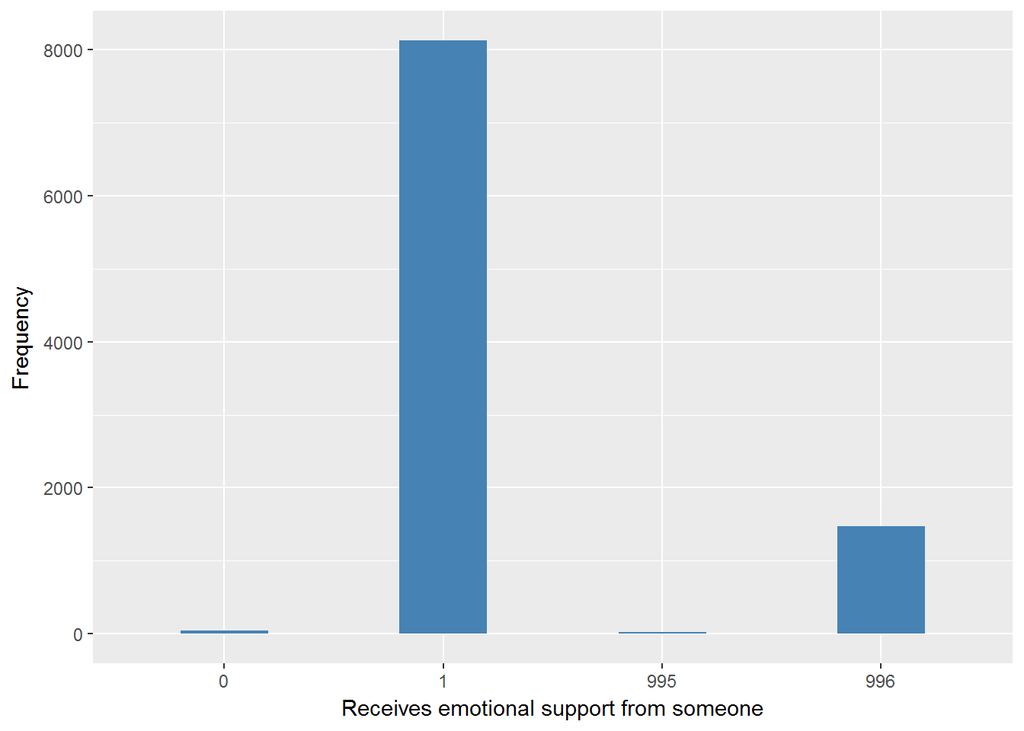

#### 2.1.7.4 Validation

## 2.2 Summary of descriptive statistics of the harmonised variable accross populations and waves

Two tables are generated:

1. Percentages of categories in each harmonised variable.
2. Frequencies and percentages of individuals with different trajectories. To avoid too large table, Only trajectories with percentages larger than 0.3 are shown.

```r
t.hds <- frq(l.hds[[1]][2])[[1]][, c(1, 2)]
for (i in seq_along(l.hds)) {
    t.hds[2 + i] <- frq(l.hds[[i]][2])[[1]][, 4]
}
t.hds[13, ] <- c("n", "sample size", sapply(l.hds, function(wave) length(wave[[1]])))
names(t.hds) <- c("val", "label", names(l.hds))
kable(t.hds)
```

| val | label | w1 | w2 | w3 | w4 | w5 | w6 | w7 |
| --- | --- | --- | --- | --- | --- | --- | --- | --- |
| 0 | No | 0.5 | 0.5 | 16.26 | 16.12 | 0.57 | 0.47 | 0.44 |
| 1 | Yes | 89.4 | 87.63 | 83.61 | 83.71 | 86.93 | 84.09 | 84.06 |
| 991 | CAPI interviewer error | 0 | 0 | 0 | 0 | 0 | 0 | 0 |
| 992 | Impute | 0 | 0 | 0 | 0 | 0 | 0 | 0 |
| 993 | Disable to measure | 0 | 0 | 0 | 0 | 0 | 0 | 0 |
| 994 | Not attempt not done | 0 | 0 | 0 | 0 | 0 | 0 | 0 |
| 995 | Does not answer | 0.29 | 0.21 | 0.01 | 0.03 | 0.15 | 0.14 | 0.22 |
| 996 | Not applicable | 9.8 | 11.66 | 0.11 | 0.14 | 12.35 | 15.3 | 15.28 |
| 997 | Refuse | 0 | 0 | 0 | 0 | 0 | 0 | 0 |
| 998 | Do not know | 0 | 0 | 0 | 0 | 0 | 0 | 0 |
| 999 | Missing | 0 | 0 | 0 | 0 | 0 | 0 | 0 |
| NA | NA | 0 | 0 | 0 | 0 | 0 | 0 | 0 |
| n | sample size | 12099 | 9432 | 9771 | 11050 | 10274 | 10601 | 9666 |

```r
dbb <- get(paste0("ELSA_m_ds_", names(l.hds)[1]))[, c("id", "emot_sup")]
for (ind in 2:length(l.hds)) {
    dbb <- merge(dbb, get(paste0("ELSA_m_ds_", names(l.hds)[ind]))[, c("id",
        "emot_sup")], by = "id", suffixes = c("", paste0(".", names(l.hds)[ind])),
        all = T)
}
names(dbb) <- c("id", names(l.hds))

v.dbb <- dbb[, 2]
for (ind in 2:length(l.hds)) {
    v.dbb <- paste(v.dbb, dbb[, ind + 1], sep = "")
}
f.dbb <- frq(v.dbb)[[1]][, c(1, 2, 4)]
kable(f.dbb[f.dbb[, 3] >= 0.3, ])
```

|  | val | frq | raw.prc |
| --- | --- | --- | --- |
| 60 | 1100NANANA | 66 | 0.36 |
| 65 | 1101111 | 114 | 0.62 |
| 79 | 110NANANANA | 136 | 0.74 |
| 84 | 1110111 | 130 | 0.70 |
| 91 | 1110NANANA | 157 | 0.85 |
| 100 | 1111111 | 3098 | 16.76 |
| 101 | 111111NA | 525 | 2.84 |
| 102 | 11111NA1 | 115 | 0.62 |
| 103 | 11111NANA | 435 | 2.35 |
| 107 | 1111NA11 | 69 | 0.37 |
| 111 | 1111NANANA | 447 | 2.42 |
| 113 | 111NA111 | 65 | 0.35 |
| 120 | 111NANANANA | 632 | 3.42 |
| 129 | 11NA1111 | 66 | 0.36 |
| 145 | 11NANANANANA | 957 | 5.18 |
| 153 | 1NA00NANANA | 84 | 0.45 |
| 170 | 1NA0NANANANA | 105 | 0.57 |
| 182 | 1NA11111 | 130 | 0.70 |
| 190 | 1NA11NANANA | 55 | 0.30 |
| 198 | 1NA1NANANANA | 114 | 0.62 |
| 223 | 1NANANANANANA | 1851 | 10.01 |
| 251 | NA111111 | 94 | 0.51 |
| 279 | NA1NANANANANA | 75 | 0.41 |
| 292 | NANA00NANANA | 125 | 0.68 |
| 294 | NANA01111 | 71 | 0.38 |
| 309 | NANA0NANANANA | 183 | 0.99 |
| 322 | NANA11111 | 557 | 3.01 |
| 323 | NANA1111NA | 108 | 0.58 |
| 325 | NANA111NANA | 75 | 0.41 |
| 330 | NANA11NANANA | 95 | 0.51 |
| 338 | NANA1NANANANA | 234 | 1.27 |
| 345 | NANANA0111 | 110 | 0.59 |
| 352 | NANANA0NANANA | 245 | 1.33 |
| 361 | NANANA1111 | 1255 | 6.79 |
| 362 | NANANA111NA | 238 | 1.29 |
| 363 | NANANA11NA1 | 72 | 0.39 |
| 364 | NANANA11NANA | 191 | 1.03 |
| 367 | NANANA1NA11 | 74 | 0.40 |
| 370 | NANANA1NANANA | 303 | 1.64 |
| 379 | NANANANANA11 | 685 | 3.70 |
| 380 | NANANANANA1NA | 227 | 1.23 |
| 382 | NANANANANANA1 | 475 | 2.57 |
| 383 | NANANANANANANA | 995 | 5.38 |

# 3 Quality estimation